# Analysis of pooled growth of large CbbM library

### Comparison MSA transformer, normalized fitness

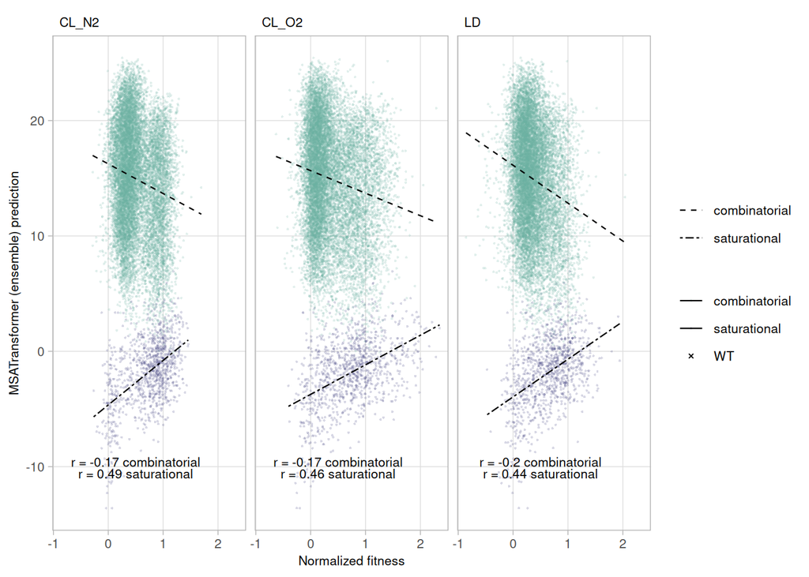

```r
lm_eqn = function(df){
    m = lm(MSA_Transform ~ norm, df);
    cor_form = cor.test(df$norm, df$MSA_Transform, method = 'pearson')
    eq <- substitute("r ="~r*~cat2, #italic(y) == a + b %.% italic(x)*" r2="~r2*" p= "~p*", Pearson's r="~r #Pearson's
         list(a = format(coef(m)[[1]], digits = 2),
              b = format(coef(m)[[2]], digits = 2),
             r2 = format(summary(m)$r.squared, digits = 3),
             r = format(cor_form$estimate[[1]], digits=2),
             p = format(cor_form$p.value[[1]], digits=2),
             cat2 = unique(df$category2)))
    as.character(as.expression(eq));
}
red_fitness_noNA_DeepSeq$category2 <- red_fitness_noNA_DeepSeq$category
red_fitness_noNA_DeepSeq[red_fitness_noNA_DeepSeq$sgRNA_target=="WT",]$category2 <- "saturational"
eq <- ddply(red_fitness_noNA_DeepSeq,.(condition, category2),lm_eqn)

scat <- ggplot(data = red_fitness_noNA_DeepSeq, aes(x = norm, y = MSA_Transform, color=category, alpha=category, linetype=category2, shape=category)) +
            geom_point(aes(size=category)) + scale_size_manual(values=combi_sat_size) + scale_shape_manual(values=combi_sat_shape) +
            geom_smooth(method = "lm", se=FALSE, color="black", formula = y ~ x, linewidth=line_width_for_plots) + xlab("Normalized fitness") + ylab("MSATransformer (ensemble) prediction") + theme_light() + theme(panel.grid.minor =element_blank(), legend.title = element_blank(), strip.background=element_rect(fill = NA, color = "white"), strip.text.x = element_text(size = 8, colour = "black", hjust = 0), axis.text=element_text(size=8), axis.title=element_text(size=8), legend.text=element_text(size=8)) + scale_alpha_manual(values=combi_sat_alpha) + scale_color_manual(values=col_combi_sat) + scale_linetype_manual(values=c("combinatorial"="dashed", "saturational"="twodash")) + facet_wrap(condition~.)
scat = scat + geom_text(data=eq,aes(x = 0.5, y =-10, label=V1), size=8, size.unit="pt", vjust=c(0,1.2,0,1.2,0,1.2), parse = TRUE, inherit.aes=FALSE) + facet_wrap(condition~.)
scat
```

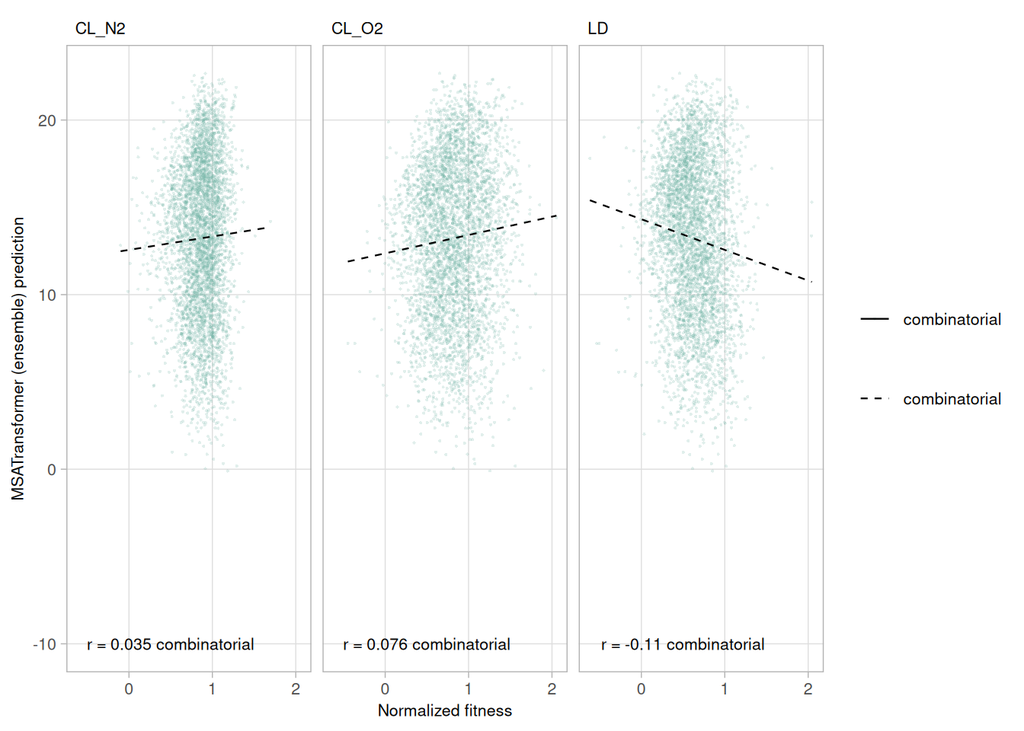

```r
ggsave("../lfcSE_weighted_outputImages/pdf/scatter_MSA_Transform_norm.pdf", scat, width=6.8, height=2, units="in")
ggsave("../lfcSE_weighted_outputImages/png/scatter_MSA_Transform_norm.png", scat, width=6.8, height=2, units="in")
red_fitness_noNA_DeepSeq_onlyComb_no4337$category2 <- red_fitness_noNA_DeepSeq_onlyComb_no4337$category
red_fitness_noNA_DeepSeq_onlyComb_no4337[red_fitness_noNA_DeepSeq_onlyComb_no4337$sgRNA_target=="WT",]$category2 <- "saturational"
eq <- ddply(red_fitness_noNA_DeepSeq_onlyComb_no4337,.(condition, category2),lm_eqn)

scat <- ggplot(data = red_fitness_noNA_DeepSeq_onlyComb_no4337, aes(x = norm, y = MSA_Transform, color=category, alpha=category, linetype=category2, shape=category)) +
            geom_point(aes(size=category)) + scale_size_manual(values=combi_sat_size) + scale_shape_manual(values=combi_sat_shape) +
            geom_smooth(method = "lm", se=FALSE, color="black", formula = y ~ x, linewidth=line_width_for_plots) + xlab("Normalized fitness") + ylab("MSATransformer (ensemble) prediction") + theme_light() + theme(panel.grid.minor =element_blank(), legend.title = element_blank(), strip.background=element_rect(fill = NA, color = "white"), strip.text.x = element_text(size = 8, colour = "black", hjust = 0), axis.text=element_text(size=8), axis.title=element_text(size=8), legend.text=element_text(size=8)) + scale_alpha_manual(values=combi_sat_alpha) + scale_color_manual(values=col_combi_sat) + scale_linetype_manual(values=c("combinatorial"="dashed", "saturational"="twodash")) + facet_wrap(condition~.)
scat = scat + geom_text(data=eq,aes(x = 0.5, y =-10, label=V1), size=8, size.unit="pt", parse = TRUE, inherit.aes=FALSE) + facet_wrap(condition~.)
scat
```

```r
ggsave("../lfcSE_weighted_outputImages/pdf/scatter_MSA_Transform_norm_noV323.pdf", scat, width=6.8, height=2, units="in")
ggsave("../lfcSE_weighted_outputImages/png/scatter_MSA_Transform_norm_noV323.png", scat, width=6.8, height=2, units="in")
```

### Comparison ProteinNPT, normalized fitness

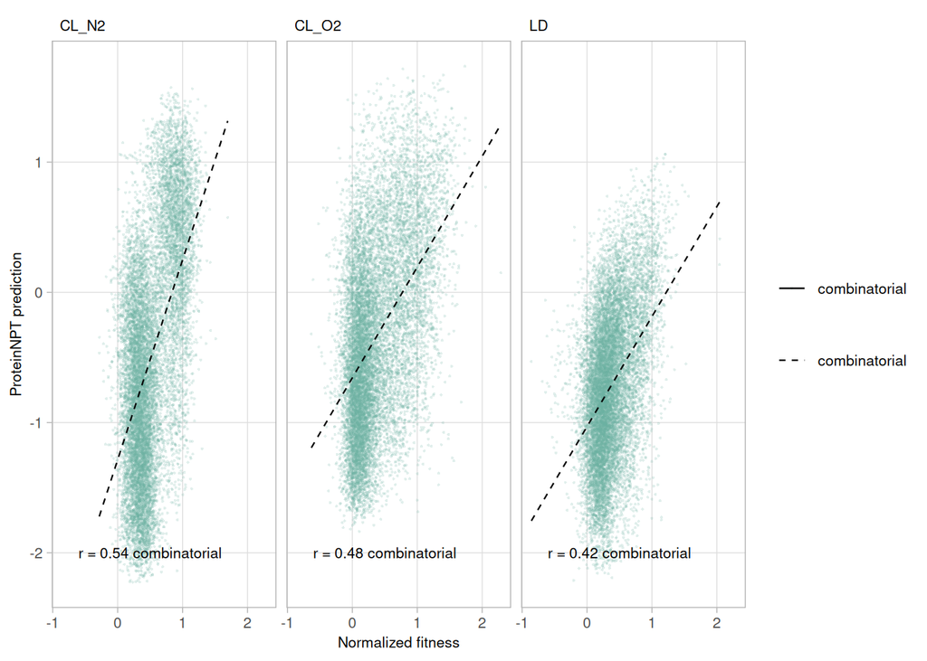

```r
df_proteinNPT <- subset(red_fitness, !is.na(red_fitness$proteinNPT_predict))

lm_eqn = function(df){
    m = lm(proteinNPT_predict ~ norm, df);
    cor_form = cor.test(df$norm, df$proteinNPT_predict, method = 'pearson')
    eq <- substitute("r ="~r*~cat2, #italic(y) == a + b %.% italic(x)*" r2="~r2*" p= "~p*", Pearson's r="~r #Pearson's
         list(a = format(coef(m)[[1]], digits = 2),
              b = format(coef(m)[[2]], digits = 2),
             r2 = format(summary(m)$r.squared, digits = 3),
             r = format(cor_form$estimate[[1]], digits=2),
             p = format(cor_form$p.value[[1]], digits=2),
             cat2 = unique(df$category2)))
    as.character(as.expression(eq));
}
df_proteinNPT$category2 <- df_proteinNPT$category
df_proteinNPT[df_proteinNPT$sgRNA_target=="WT",]$category2 <- "saturational"
eq <- ddply(df_proteinNPT,.(condition, category2),lm_eqn)

scat <- ggplot(data = df_proteinNPT, aes(x = norm, y = proteinNPT_predict, color=category, alpha=category, linetype=category2, shape=category)) +
            geom_point(aes(size=category)) + scale_size_manual(values=combi_sat_size) + scale_shape_manual(values=combi_sat_shape) +
            geom_smooth(method = "lm", se=FALSE, color="black", formula = y ~ x, linewidth=line_width_for_plots) + xlab("Normalized fitness") + ylab("ProteinNPT prediction") + theme_light() + theme(panel.grid.minor =element_blank(), legend.title = element_blank(), strip.background=element_rect(fill = NA, color = "white"), strip.text.x = element_text(size = 8, colour = "black", hjust = 0), axis.text=element_text(size=8), axis.title=element_text(size=8), legend.text=element_text(size=8)) + scale_alpha_manual(values=combi_sat_alpha) + scale_color_manual(values=col_combi_sat) + scale_linetype_manual(values=c("combinatorial"="dashed", "saturational"="twodash")) + facet_wrap(condition~.)
scat = scat + geom_text(data=eq,aes(x = 0.5, y =-2, label=V1), size=8, size.unit="pt", parse = TRUE, inherit.aes=FALSE) + facet_wrap(condition~.)
scat
```

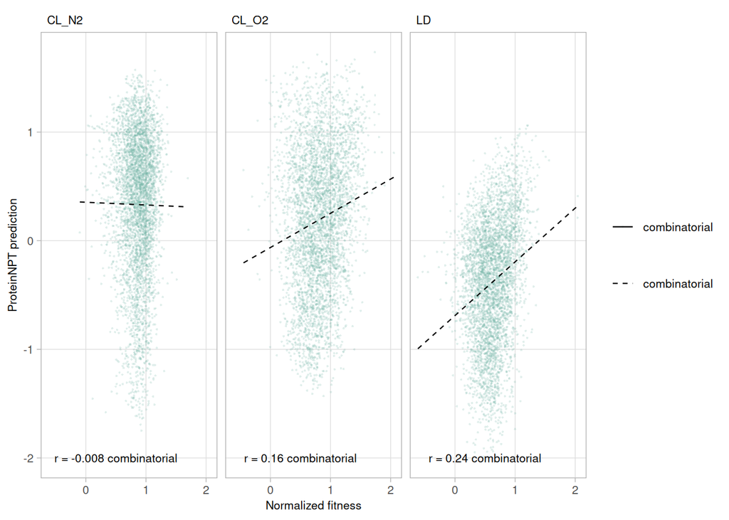

```r
ggsave("../lfcSE_weighted_outputImages/pdf/scatter_proteinNPT_norm.pdf", scat, width=6.8, height=2, units="in")
ggsave("../lfcSE_weighted_outputImages/png/scatter_proteinNPT_norm.png", scat, width=6.8, height=2, units="in")

df_proteinNPT_noV323 <- subset(df_proteinNPT, !grepl("V337", df_proteinNPT$sgRNA_target))

df_proteinNPT_noV323$category2 <- df_proteinNPT_noV323$category
df_proteinNPT_noV323[df_proteinNPT_noV323$sgRNA_target=="WT",]$category2 <- "saturational"
eq <- ddply(df_proteinNPT_noV323,.(condition, category2),lm_eqn)

scat <- ggplot(data = df_proteinNPT_noV323, aes(x = norm, y = proteinNPT_predict, color=category, alpha=category, linetype=category2, shape=category)) +
            geom_point(aes(size=category)) + scale_size_manual(values=combi_sat_size) + scale_shape_manual(values=combi_sat_shape) +
            geom_smooth(method = "lm", se=FALSE, color="black", formula = y ~ x, linewidth=line_width_for_plots) + xlab("Normalized fitness") + ylab("ProteinNPT prediction") + theme_light() + theme(panel.grid.minor =element_blank(), legend.title = element_blank(), strip.background=element_rect(fill = NA, color = "white"), strip.text.x = element_text(size = 8, colour = "black", hjust = 0), axis.text=element_text(size=8), axis.title=element_text(size=8), legend.text=element_text(size=8)) + scale_alpha_manual(values=combi_sat_alpha) + scale_color_manual(values=col_combi_sat) + scale_linetype_manual(values=c("combinatorial"="dashed", "saturational"="twodash")) + facet_wrap(condition~.)
scat = scat + geom_text(data=eq,aes(x = 0.5, y =-2, label=V1), size=8, size.unit="pt", parse = TRUE, inherit.aes=FALSE) + facet_wrap(condition~.)
scat
```

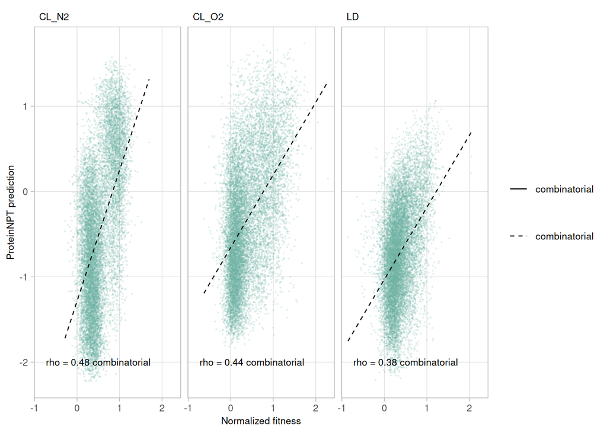

```r
ggsave("../lfcSE_weighted_outputImages/pdf/scatter_proteinNPT_norm_noV323.pdf", scat, width=6.8, height=2, units="in")
ggsave("../lfcSE_weighted_outputImages/png/scatter_proteinNPT_norm_noV323.png", scat, width=6.8, height=2, units="in")


lm_eqn = function(df){
    m = lm(proteinNPT_predict ~ norm, df);
    cor_form = cor.test(df$norm, df$proteinNPT_predict, method = 'spearman')
    eq <- substitute("rho ="~r*~cat2, #italic(y) == a + b %.% italic(x)*" r2="~r2*" p= "~p*", Pearson's r="~r #Pearson's
         list(a = format(coef(m)[[1]], digits = 2),
              b = format(coef(m)[[2]], digits = 2),
             r2 = format(summary(m)$r.squared, digits = 3),
             r = format(cor_form$estimate[[1]], digits=2),
             p = format(cor_form$p.value[[1]], digits=2),
             cat2 = unique(df$category2)))
    as.character(as.expression(eq));
}
df_proteinNPT$category2 <- df_proteinNPT$category
df_proteinNPT[df_proteinNPT$sgRNA_target=="WT",]$category2 <- "saturational"
eq <- ddply(df_proteinNPT,.(condition, category2),lm_eqn)
scat <- ggplot(data = df_proteinNPT, aes(x = norm, y = proteinNPT_predict, color=category, alpha=category, linetype=category2, shape=category)) +
            geom_point(aes(size=category)) + scale_size_manual(values=combi_sat_size) + scale_shape_manual(values=combi_sat_shape) +
            geom_smooth(method = "lm", se=FALSE, color="black", formula = y ~ x, linewidth=line_width_for_plots) + xlab("Normalized fitness") + ylab("ProteinNPT prediction") + theme_light() + theme(panel.grid.minor =element_blank(), legend.title = element_blank(), strip.background=element_rect(fill = NA, color = "white"), strip.text.x = element_text(size = 8, colour = "black", hjust = 0), axis.text=element_text(size=8), axis.title=element_text(size=8), legend.text=element_text(size=8)) + scale_alpha_manual(values=combi_sat_alpha) + scale_color_manual(values=col_combi_sat) + scale_linetype_manual(values=c("combinatorial"="dashed", "saturational"="twodash")) + facet_wrap(condition~.)
scat = scat + geom_text(data=eq,aes(x = 0.5, y =-2, label=V1), size=8, size.unit="pt", parse = TRUE, inherit.aes=FALSE) + facet_wrap(condition~.)
scat
```

```r
ggsave("../lfcSE_weighted_outputImages/pdf/scatter_proteinNPT_norm_spearman.pdf", scat, width=6.8, height=2, units="in")
ggsave("../lfcSE_weighted_outputImages/png/scatter_proteinNPT_norm_spearman.png", scat, width=6.8, height=2, units="in")
```

### Comparison MSA transformer, ProteinNPT

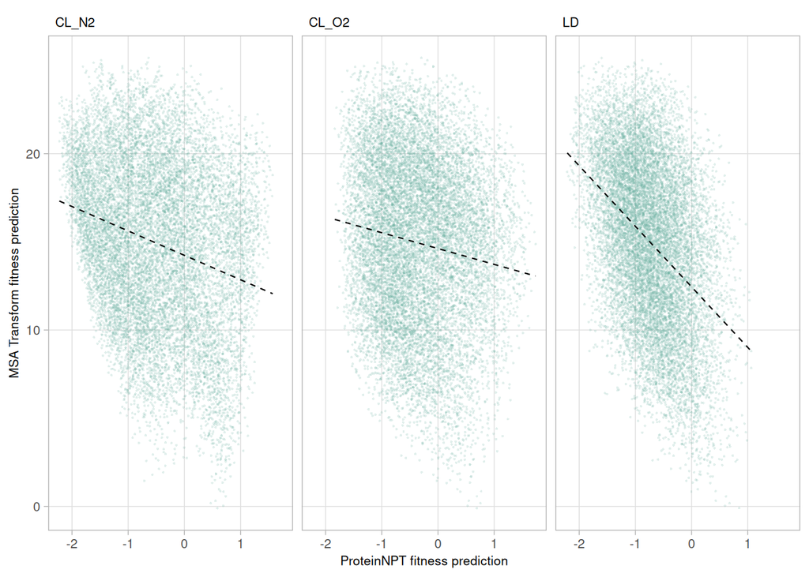

```r
scat <- ggplot(df_proteinNPT, aes(x=proteinNPT_predict, y=MSA_Transform, color=category, alpha=category, linetype=category, shape=category, size=category)) + geom_point() + scale_shape_manual(values=combi_sat_shape) + scale_size_manual(values=combi_sat_size) + geom_smooth(method = "lm", se=FALSE, color="black", formula = y ~ x, linewidth=line_width_for_plots) + scale_linetype_manual(values=c("combinatorial"="dashed", "saturational"="twodash")) + theme_light() + xlab("ProteinNPT fitness prediction") + ylab("MSA Transform fitness prediction") + scale_alpha_manual(values=combi_sat_alpha) + scale_color_manual(values=col_combi_sat) + theme(panel.grid.minor =element_blank(), legend.position = "none", strip.background=element_rect(fill = NA, color = "white"), strip.text.x = element_text(size = 8, colour = "black", hjust = 0), axis.text=element_text(size=8), axis.title=element_text(size=8), legend.text=element_text(size=8), legend.title = element_blank()) + facet_wrap(condition~.)
scat
```

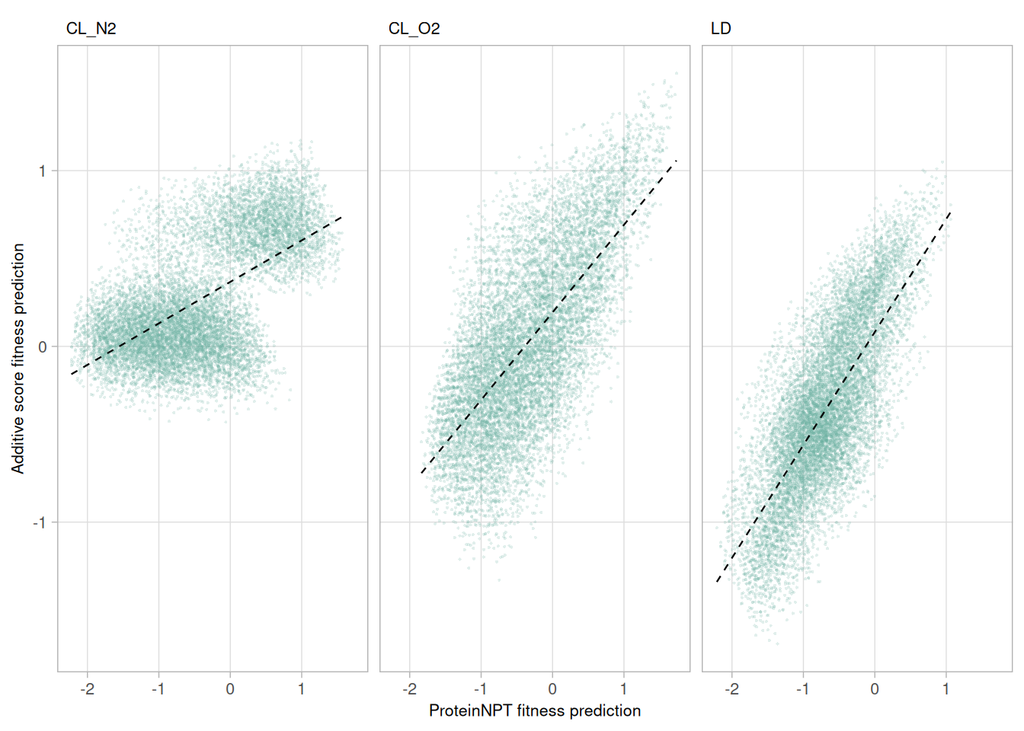

```r
ggsave("../lfcSE_weighted_outputImages/pdf/scatter_MSA_Transform_proteinNPT.pdf", scat, width=2, height=2, units="in")
ggsave("../lfcSE_weighted_outputImages/png/scatter_MSA_Transform_proteinNPT.png", scat, width=2, height=2, units="in")

scat <- ggplot(df_proteinNPT, aes(x=proteinNPT_predict, y=additive_score, color=category, alpha=category, linetype=category, shape=category, size=category)) + geom_point() + scale_shape_manual(values=combi_sat_shape) + scale_size_manual(values=combi_sat_size) + geom_smooth(method = "lm", se=FALSE, color="black", formula = y ~ x, linewidth=line_width_for_plots) + scale_linetype_manual(values=c("combinatorial"="dashed", "saturational"="twodash")) + theme_light() + xlab("ProteinNPT fitness prediction") + ylab("Additive score fitness prediction") + scale_alpha_manual(values=combi_sat_alpha) + scale_color_manual(values=col_combi_sat) + theme(panel.grid.minor =element_blank(), legend.position = "none", strip.background=element_rect(fill = NA, color = "white"), strip.text.x = element_text(size = 8, colour = "black", hjust = 0), axis.text=element_text(size=8), axis.title=element_text(size=8), legend.text=element_text(size=8), legend.title = element_blank()) + facet_wrap(condition~.)
scat
```

```r
ggsave("../lfcSE_weighted_outputImages/pdf/scatter_additiveScore_proteinNPT.pdf", scat, width=2, height=2, units="in")
ggsave("../lfcSE_weighted_outputImages/png/scatter_additiveScore_proteinNPT.png", scat, width=2, height=2, units="in")
```

## Correlation conservation to fitness

```r
cor_subs <- unique(subset(fitness_data, fitness_data$category=="saturational" | fitness_data$category=="combiANDsatur")[,c("aa_pos","norm","conservationScore","category","condition")])
cor_subs[cor_subs$category=="combiANDsatur",]$category <- "saturational"
cor_subs <- subset(cor_subs, !is.na(cor_subs$conservationScore))
cor_subs_2 <- cor_subs %>% dplyr::group_by(aa_pos, condition) %>%
  dplyr::summarize(
    .groups="keep",
    averag_fitness=mean(norm)
  )
cor_subs <- left_join(cor_subs_2,cor_subs[,c("aa_pos","conservationScore","category")])
```

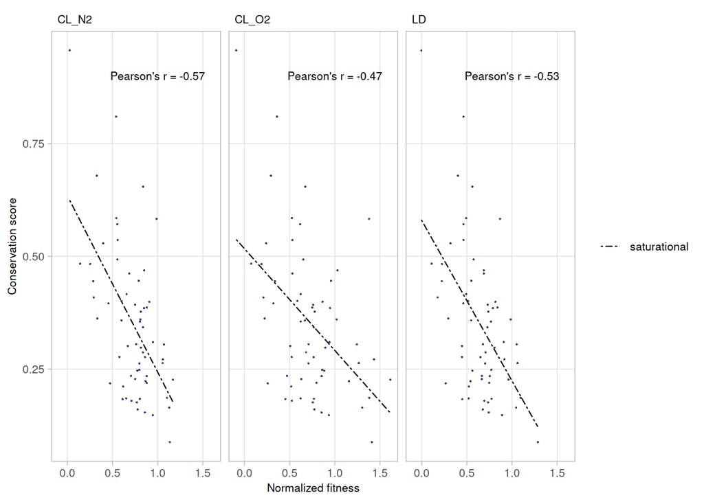

```r
lm_eqn = function(df){
    m = lm(conservationScore ~ averag_fitness, df);
    cor_form = cor.test(df$averag_fitness, df$conservationScore, method = 'pearson')
    eq <- substitute("Pearson's r ="~r, #italic(y) == a + b %.% italic(x)*" r2="~r2*" p= "~p*", Pearson's r="~r
         list(a = format(coef(m)[[1]], digits = 2),
              b = format(coef(m)[[2]], digits = 2),
             r2 = format(summary(m)$r.squared, digits = 3),
             r = format(cor_form$estimate[[1]], digits=2),
             p = format(cor_form$p.value[[1]], digits=2)))
    as.character(as.expression(eq));
}
eq <- ddply(cor_subs,.(condition),lm_eqn)

scat <- ggplot(data = cor_subs, aes(x = averag_fitness, y = conservationScore, color=category, alpha=category, linetype=category)) +
            geom_point(aes(size=category, shape=category))  + scale_size_manual(values=combi_sat_size) + scale_shape_manual(values=combi_sat_shape) +
            geom_smooth(method = "lm", se=FALSE, color="black", formula = y ~ x, linewidth=line_width_for_plots) + xlab("Normalized fitness") + ylab("Conservation score") + theme_light() + theme(panel.grid.minor =element_blank(), legend.title = element_blank(), strip.background=element_rect(fill = NA, color = "white"), strip.text.x = element_text(size = 8, colour = "black", hjust = 0), axis.text=element_text(size=8), axis.title=element_text(size=8), legend.text=element_text(size=8)) + scale_alpha_manual(values=combi_sat_alpha) + scale_color_manual(values=col_combi_sat) + scale_linetype_manual(values=c("combinatorial"="dashed", "saturational"="twodash")) + facet_wrap(condition~.)
scat = scat + geom_text(data=eq,aes(x = 1, y =0.9, label=V1), size=8, size.unit="pt", parse = TRUE, inherit.aes=FALSE) + facet_wrap(condition~.)
scat
```

```r
ggsave("../lfcSE_weighted_outputImages/pdf/conservation_norm.pdf", scat, width=6.8, height=2, units="in")
ggsave("../lfcSE_weighted_outputImages/png/conservation_norm.png", scat, width=6.8, height=2, units="in")
```

## Correlation surface exposure to fitness

```r
dotsize_surface <- 0.4
surface <- unique(subset(fitness_data, fitness_data$category=="saturational" | fitness_data$category=="combiANDsatur")[,c("aa_pos","norm","relSAS", "dimer","category","condition")])
surface[surface$category=="combiANDsatur",]$category <- "saturational"
surface <- subset(surface, !is.na(surface$relSAS))
surface_2 <- surface %>% dplyr::group_by(aa_pos, condition) %>%
  dplyr::summarize(
    .groups="keep",
    averag_fitness=mean(norm)
  )
surface <- left_join(surface_2,surface[,c("aa_pos","relSAS", "dimer","category")])
```

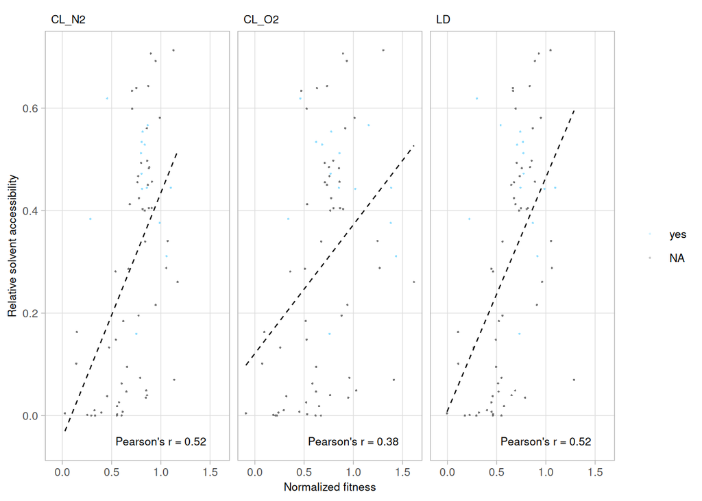

```r
lm_eqn = function(df){
    m = lm(relSAS ~ averag_fitness, df);
    cor_form = cor.test(df$averag_fitness, df$relSAS, method = 'pearson')
    eq <- substitute("Pearson's r ="~r, #italic(y) == a + b %.% italic(x)*" r2="~r2*" p= "~p*", Pearson's r="~r
         list(a = format(coef(m)[[1]], digits = 2),
              b = format(coef(m)[[2]], digits = 2),
             r2 = format(summary(m)$r.squared, digits = 3),
             r = format(cor_form$estimate[[1]], digits=2),
             p = format(cor_form$p.value[[1]], digits=2)))
    as.character(as.expression(eq));
}
eq <- ddply(surface,.(condition),lm_eqn)

scat <- ggplot(data = surface, aes(x = averag_fitness, y = relSAS, color=dimer)) +
            geom_point(size=dotsize_surface, shape=pointshape, alpha=alphalevel) +
            geom_smooth(method = "lm", se=FALSE, color="black", formula = y ~ x, linetype="dashed", linewidth=line_width_for_plots) + xlab("Normalized fitness") + ylab("Relative solvent accessibility") + theme_light() + theme(panel.grid.minor =element_blank(), legend.title = element_blank(), strip.background=element_rect(fill = NA, color = "white"), strip.text.x = element_text(size = 8, colour = "black", hjust = 0), axis.text=element_text(size=8), axis.title=element_text(size=8), legend.text=element_text(size=8)) + scale_color_manual(values=c("#93dfffff"), na.value="#777777") + facet_wrap(condition~.)
scat = scat + geom_text(data=eq,aes(x = 1.0, y =-0.05, label=V1), size=8, size.unit="pt", parse = TRUE, inherit.aes=FALSE) + facet_wrap(condition~.)
scat
```

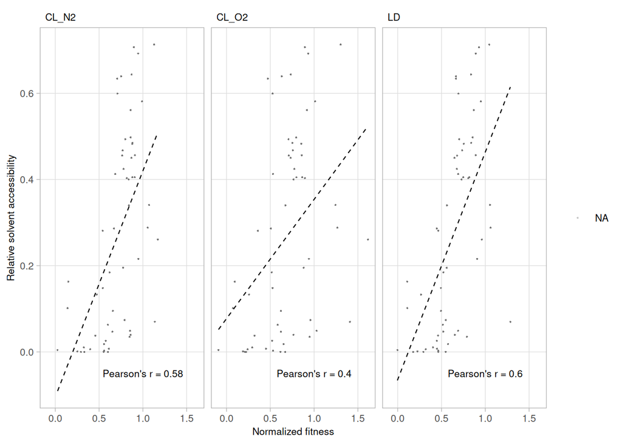

```r
ggsave("../lfcSE_weighted_outputImages/pdf/relSAS_norm.pdf", scat, width=7, height=2, units="in")
ggsave("../lfcSE_weighted_outputImages/png/relSAS_norm.png", scat, width=30, height=18, units="cm")


surface_noDimer <- subset(surface, is.na(surface$dimer))
eq <- ddply(surface_noDimer,.(condition),lm_eqn)

scat <- ggplot(data = surface_noDimer, aes(x = averag_fitness, y = relSAS, color=dimer)) +
            geom_point(size=dotsize_surface, shape=pointshape, alpha=alphalevel) +
            geom_smooth(method = "lm", se=FALSE, color="black", formula = y ~ x, linetype="dashed", linewidth=line_width_for_plots) + xlab("Normalized fitness") + ylab("Relative solvent accessibility") + theme_light() + theme(panel.grid.minor =element_blank(), legend.title = element_blank(), strip.background=element_rect(fill = NA, color = "white"), strip.text.x = element_text(size = 8, colour = "black", hjust = 0), axis.text=element_text(size=8), axis.title=element_text(size=8), legend.text=element_text(size=8)) + scale_color_manual(values=c("#93dfffff"), na.value="#777777") + facet_wrap(condition~.)
scat = scat + geom_text(data=eq,aes(x = 1.0, y =-0.05, label=V1), size=8, size.unit = "pt", parse = TRUE, inherit.aes=FALSE) + facet_wrap(condition~.)
scat
```

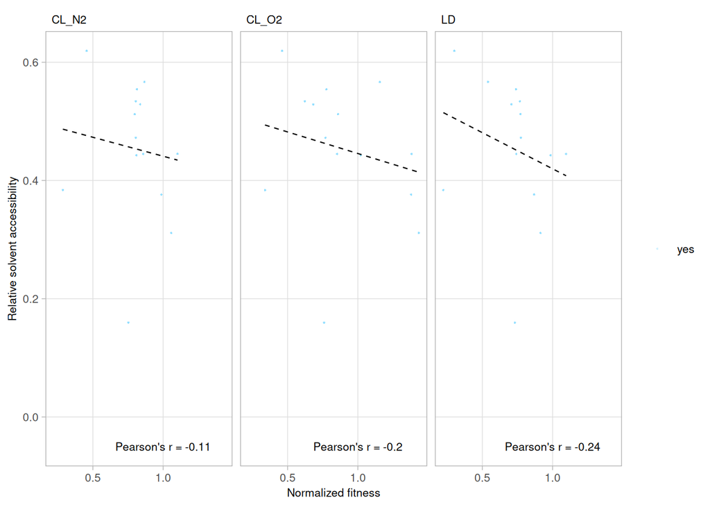

```r
ggsave("../lfcSE_weighted_outputImages/pdf/relSAS_norm_noDimer.pdf", scat, width=6.8, height=2, units="in")
ggsave("../lfcSE_weighted_outputImages/png/relSAS_norm_noDimer.png", scat, width=6.8, height=2, units="in")


surface_Dimer <- subset(surface, !is.na(surface$dimer))
eq <- ddply(surface_Dimer,.(condition),lm_eqn)

scat <- ggplot(data = surface_Dimer, aes(x = averag_fitness, y = relSAS, color=dimer)) +
            geom_point(size=dotsize_surface, shape=pointshape, alpha=alphalevel) +
            geom_smooth(method = "lm", se=FALSE, color="black", formula = y ~ x, linetype="dashed", linewidth=line_width_for_plots) + xlab("Normalized fitness") + ylab("Relative solvent accessibility") + theme_light() + theme(panel.grid.minor =element_blank(), legend.title = element_blank(), strip.background=element_rect(fill = NA, color = "white"), strip.text.x = element_text(size = 8, colour = "black", hjust = 0), axis.text=element_text(size=8), axis.title=element_text(size=8), legend.text=element_text(size=8)) + scale_color_manual(values=c("#93dfffff"), na.value="#777777") + facet_wrap(condition~.)
scat = scat + geom_text(data=eq,aes(x = 1.0, y =-0.05, label=V1), size=8, size.unit="pt", parse = TRUE, inherit.aes=FALSE) + facet_wrap(condition~.)
scat
```

```r
ggsave("../lfcSE_weighted_outputImages/pdf/relSAS_norm_onlyDimer.pdf", scat, width=6.8, height=2, units="in")
ggsave("../lfcSE_weighted_outputImages/png/relSAS_norm_onlyDimer.png", scat, width=30, height=18, units="cm")
```

# Comparing different conditions

A comparison between different conditions helps to identify variants which behave different in different conditions, e.g. because of an enhanced specificity or higher compatibility with light-dark cycles.

## Compare N2 and O2 gas feeds

```r
red_fitness <- unique(fitness_data[,c("sgRNA_target", "norm", "condition", "p_fit_adj_WT", "num_barcodes", "category")])
wide_fitness <- pivot_wider(red_fitness, values_from =c(norm,p_fit_adj_WT), names_from=condition)
wide_fitness$sgRNA_target <- factor(wide_fitness$sgRNA_target, levels=c(unique(subset(wide_fitness, wide_fitness$sgRNA_target != "WT"))$sgRNA_target, "WT"))
wide_fitness$WT_not_WT <- "notWT"
wide_fitness[wide_fitness$sgRNA_target=="WT",]$WT_not_WT <- "WT"

# set some plotting parameters
WT_shape <- c("notWT"=16, "WT"=4)
WT_alpha <- c("notWT"=0.2, "WT"=1.0)
WT_size <- c("notWT"=0.3, "WT"=0.5)
CLO2_CLN2_cutoff <- 0.25
barcode_cutoff <- 2
adjp_cutoff <- 0.05

# extract subsets from big data frames to test if significant differences
subset_signif_highO2 <- subset(fitness_data, fitness_data$sgRNA_target %in% subset(wide_fitness, wide_fitness$norm_CL_O2>1.0 & wide_fitness$p_fit_adj_WT_CL_O2<0.05)$sgRNA_target)
subset_signif_highLD <- subset(fitness_data, fitness_data$sgRNA_target %in% subset(wide_fitness, wide_fitness$norm_LD > wide_fitness$norm_CL_O2 & wide_fitness$norm_LD > 0.9)$sgRNA_target)

# prepare plotting, calculate lm to check distance from it (assuming linear regression gives better 1:1 than line through origin)
lm_CLO2_CLN2 <- lm(norm_CL_N2 ~ norm_CL_O2, wide_fitness)
summary(lm_CLO2_CLN2)
```

```
##
## Call:
## lm(formula = norm_CL_N2 ~ norm_CL_O2, data = wide_fitness)
##
## Residuals:
##      Min       1Q   Median       3Q      Max
## -1.03132 -0.07939  0.01898  0.09884  0.88126
##
## Coefficients:
##             Estimate Std. Error t value Pr(>|t|)
## (Intercept) 0.266196   0.001775   150.0   <2e-16 ***
## norm_CL_O2  0.653940   0.003040   215.1   <2e-16 ***
## ---
## Signif. codes:  0 '***' 0.001 '**' 0.01 '*' 0.05 '.' 0.1 ' ' 1
##
## Residual standard error: 0.1505 on 13964 degrees of freedom
## Multiple R-squared:  0.7681, Adjusted R-squared:  0.7681
## F-statistic: 4.626e+04 on 1 and 13964 DF,  p-value: < 2.2e-16
```

```r
correlation <- cor.test(wide_fitness$norm_CL_O2, wide_fitness$norm_CL_N2, method = 'spearman')
correlation
```

```
##
##  Spearman's rank correlation rho
##
## data:  wide_fitness$norm_CL_O2 and wide_fitness$norm_CL_N2
## S = 7.8282e+10, p-value < 2.2e-16
## alternative hypothesis: true rho is not equal to 0
## sample estimates:
##       rho
## 0.8275755
```

```r
correlation <- cor.test(wide_fitness$norm_CL_O2, wide_fitness$norm_CL_N2, method = 'pearson')
correlation
```

```
##
##  Pearson's product-moment correlation
##
## data:  wide_fitness$norm_CL_O2 and wide_fitness$norm_CL_N2
## t = 215.08, df = 13964, p-value < 2.2e-16
## alternative hypothesis: true correlation is not equal to 0
## 95 percent confidence interval:
##  0.8725266 0.8802195
## sample estimates:
##       cor
## 0.8764289
```

```r
wide_fitness_CL_OL <- wide_fitness
wide_fitness_CL_OL$distance_lm <- wide_fitness_CL_OL$norm_CL_N2 - (lm_CLO2_CLN2$coefficients[1] + lm_CLO2_CLN2$coefficients[2] * wide_fitness_CL_OL$norm_CL_O2)
wide_fitness_CL_OL[order(wide_fitness_CL_OL$distance_lm, decreasing = FALSE),][1:10,]
```

| sgRNA_target | num_barcodes | category | norm_CL_N2 | norm_CL_O2 | norm_LD | p_fit_adj_WT_CL_N2 | p_fit_adj_WT_CL_O2 | p_fit_adj_WT_LD | WT_not_WT | distance_lm |
| --- | --- | --- | --- | --- | --- | --- | --- | --- | --- | --- |
| M154D,H265R,V337S,S446T | 1 | combinatorial | 0.1308536 | 1.370122 | 0.7949560 | 0.08023996 | 0.1511790 | 0.61433860 | notWT | -1.0313213 |
| H141L,M154K,K261A,H265R,V337A | 1 | combinatorial | 0.2062316 | 1.478284 | 1.0546306 | 0.08023996 | 0.1511790 | 0.91611635 | notWT | -1.0266745 |
| Y379G | 1 | saturational | 0.2693641 | 1.540111 | 0.5506254 | 0.08023996 | 0.1511790 | 0.07993531 | notWT | -1.0039728 |
| H141L,M154A,H265K,V337S | 1 | combinatorial | 0.3159218 | 1.564646 | 1.1471773 | 0.08023996 | 0.1511790 | 0.48787435 | notWT | -0.9734598 |
| M154D,K261D,H265E,Q406E | 1 | combinatorial | 0.3332440 | 1.585035 | 1.3061876 | 0.08023996 | 0.1511790 | 0.22154948 | notWT | -0.9694708 |
| H141V,K261D,V337S,Q406D,S446I | 1 | combinatorial | 0.3522087 | 1.591406 | 0.5459323 | 0.08023996 | 0.1511790 | 0.07993531 | notWT | -0.9546722 |
| K27M | 1 | saturational | 0.4630741 | 1.692428 | 1.6530931 | 0.08023996 | 0.1511790 | 0.07993531 | notWT | -0.9098695 |
| H141L,M154S,H265K,V337A,Q406E,S446I | 1 | combinatorial | 0.2739810 | 1.328285 | 1.0201227 | 0.08023996 | 0.1511790 | 0.97297478 | notWT | -0.8608347 |
| H141L,M154D,K261F,H265E,V337A,Q406D,S446T | 1 | combinatorial | 0.1624614 | 1.105560 | 0.5851698 | 0.08023996 | 0.5521063 | 0.22154948 | notWT | -0.8267056 |
| H141L,M154A,K261D,H265A,V337S,S446T | 1 | combinatorial | 0.3875468 | 1.428254 | 1.0562510 | 0.08023996 | 0.1511790 | 0.91611635 | notWT | -0.8126424 |

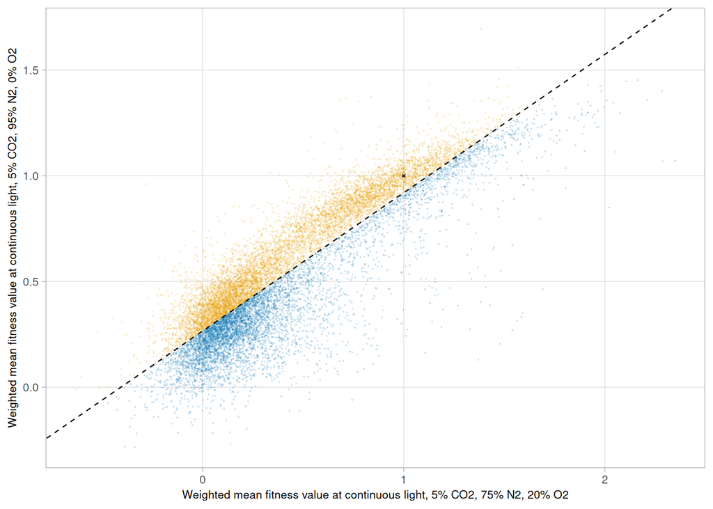

```r
# coloring according to differential expression
wide_fitness_CL_OL$diff <- "NO"
wide_fitness_CL_OL$diff[wide_fitness_CL_OL$distance_lm > 0] <- "CL_N2"
wide_fitness_CL_OL$diff[wide_fitness_CL_OL$distance_lm < 0] <- "CL_O2"
#wide_fitness_CL_OL$diff[wide_fitness_CL_OL$distance_lm > CLO2_CLN2_cutoff] <- "CL_N2" # in case we care for cut-off for minimal distance from linear regression
#wide_fitness_CL_OL$diff[wide_fitness_CL_OL$distance_lm < (-CLO2_CLN2_cutoff)] <- "CL_O2" # in case we care for cut-off for minimal distance from linear regression
wide_fitness_CL_OL[wide_fitness_CL_OL$sgRNA_target=="WT",]$diff <- "WT"
dotplot_colors <- c(col_conditions, "NO"="#d3d3d3b2", "orange", "WT"="black")

# prepare labels for plot
wide_fitness_CL_OL$delabel <- NA
wide_fitness_CL_OL$delabel[wide_fitness_CL_OL$diff !="NO"] <- as.character(wide_fitness_CL_OL$sgRNA_target[wide_fitness_CL_OL$diff != "NO"])

p <- ggplot(wide_fitness_CL_OL, aes(x=norm_CL_O2, y=norm_CL_N2, color=diff, shape=WT_not_WT)) + geom_point(aes(size=WT_not_WT, alpha=WT_not_WT), show.legend=FALSE) + scale_shape_manual(values=WT_shape) + scale_size_manual(values=WT_size) + scale_alpha_manual(values=WT_alpha) + theme_light() + labs(y="Weighted mean fitness value at continuous light, 5% CO2, 95% N2, 0% O2", x="Weighted mean fitness value at continuous light, 5% CO2, 75% N2, 20% O2") + theme(legend.position = "none", panel.grid.minor = element_blank()) + geom_abline(intercept=lm_CLO2_CLN2$coefficients[1],slope=lm_CLO2_CLN2$coefficients[2],linetype="dashed",color="black", linewidth=line_width_for_plots) + scale_colour_manual(values = dotplot_colors) + theme(panel.grid.minor = element_blank(), strip.background=element_rect(fill = NA, color = "white"), strip.text.x = element_text(size = 8, colour = "black", hjust = 0), axis.text=element_text(size=8), axis.title=element_text(size=8), legend.text=element_text(size=8)) #+ xlim(-6, +7) +ylim(-6,+7)
ggsave(filename = "../lfcSE_weighted_outputImages/pdf/wfitness_CLN2_CLO2_withoutSignif_wo-labels.pdf", plot=p, width=4, height=4, units="cm")
ggsave(filename = "../lfcSE_weighted_outputImages/png/wfitness_CLN2_CLO2_withoutSignif_wo-labels.png", plot=p, width=4, height=4, units="cm")
p
```

Use Wilcoxon signed rank exact test to check if barcodes for the same variant behave significiantly different between the two tested conditions.

```r
subset_signif_highO2 <- subset(subset_signif_highO2, subset_signif_highO2$condition %in% c("CL_N2", "CL_O2"))

get_controls <- function(cond_spec, sgRNA_spec){
  control_table <- subset_signif_highO2[subset_signif_highO2$condition != unique(cond_spec) & subset_signif_highO2$sgRNA_target == unique(sgRNA_spec) & subset_signif_highO2$time == 0,]
  control_table$fitness
}

subset_signif_highO2 <- dplyr::left_join(
  subset_signif_highO2,
  subset_signif_highO2 %>%
    dplyr::group_by(sgRNA_target, condition, time) %>%
    dplyr::summarize(
      .groups = "keep",
      # apply Wilcoxon rank sum test against other condition
      p_fitness_condition = stats::wilcox.test(
        x = fitness,
        y = get_controls(condition, sgRNA_target),
        paired = TRUE,
        alternative = "two.sided"
        )$p.value
      ),
  by = c("sgRNA_target", "condition", "time")
  )

subset_signif_highO2 <- subset_signif_highO2 %>%
  group_by(condition, time) %>%
  mutate(
    p_fitness_condition_adj = stats::p.adjust(p_fitness_condition, method = "BH")
    )
```

Plot part of data set which was tested for significant differences and highlight variants which were found to be significant.

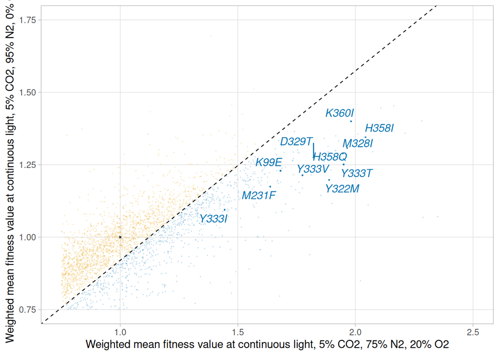

```r
subset_signif_highO2_red <- unique(subset_signif_highO2[,c("sgRNA_target", "norm", "condition", "num_barcodes", "p_fitness_condition_adj")])
subset_signif_highO2_red <- pivot_wider(subset_signif_highO2_red, values_from =c(norm,p_fitness_condition_adj), names_from=condition)

# alpha, size and labels according to significance
wide_fitness_CL_OL$signif <- "NO"
wide_fitness_CL_OL$signif[wide_fitness_CL_OL$sgRNA_target %in% unique(subset(subset_signif_highO2, subset_signif_highO2$p_fitness_condition_adj < adjp_cutoff))$sgRNA_target] <- "SIG"
wide_fitness_CL_OL$delabel <- NA
wide_fitness_CL_OL$delabel[wide_fitness_CL_OL$signif =="SIG"] <- as.character(wide_fitness_CL_OL$sgRNA_target[wide_fitness_CL_OL$signif =="SIG"])
wide_fitness_CL_OL[wide_fitness_CL_OL$sgRNA_target=="WT",]$signif <- "WT" # to ensure WT is visible
signif_size <- c("NO"=0.3, "SIG"=0.5, "WT"=0.5)
signif_alpha <- c("NO"=0.2, "SIG"=0.9, "WT"=1.0)

p <- ggplot(wide_fitness_CL_OL, aes(x=norm_CL_O2, y=norm_CL_N2, color=diff, label=delabel, shape=WT_not_WT)) + scale_shape_manual(values=WT_shape) + geom_point(aes(size=signif, alpha=signif), show.legend=FALSE) + scale_size_manual(values=signif_size) + scale_alpha_manual(values=signif_alpha) + theme_light() + labs(y="Weighted mean fitness value at continuous light, 5% CO2, 95% N2, 0% O2", x="Weighted mean fitness value at continuous light, 5% CO2, 75% N2, 20% O2") + theme(legend.position = "none", panel.grid.minor = element_blank()) + geom_abline(intercept=lm_CLO2_CLN2$coefficients[1],slope=lm_CLO2_CLN2$coefficients[2],linetype="dashed",color="black", linewidth=line_width_for_plots) + scale_colour_manual(values = dotplot_colors) + geom_text_repel(fontface="italic") + xlim(0.75, 2.5) +ylim(0.75,1.75)
p
```

```r
ggsave(filename = "../lfcSE_weighted_outputImages/pdf/wfitness_CLN2_CLO2_Wilcox_signif.pdf", plot=p, width=12.5, height=12.5, units="cm")
ggsave(filename = "../lfcSE_weighted_outputImages/png/wfitness_CLN2_CLO2_Wilcox_signif.png", plot=p, width=12.5, height=12.5, units="cm")
wide_fitness_CL_OL[wide_fitness_CL_OL$signif=="SIG",][order(wide_fitness_CL_OL[wide_fitness_CL_OL$signif=="SIG",]$norm_CL_O2, decreasing=TRUE),]
```

| sgRNA_target | num_barcodes | category | norm_CL_N2 | norm_CL_O2 | norm_LD | p_fit_adj_WT_CL_N2 | p_fit_adj_WT_CL_O2 | p_fit_adj_WT_LD | WT_not_WT | distance_lm | diff | delabel | signif |
| --- | --- | --- | --- | --- | --- | --- | --- | --- | --- | --- | --- | --- | --- |
| H358I | 11 | saturational | 1.345127 | 2.042853 | 1.0094045 | 2.681402e-07 | 1.532124e-06 | 1.000000e+00 | notWT | -0.2569736 | CL_O2 | H358I | SIG |
| K360I | 14 | saturational | 1.399794 | 1.981698 | 1.3774450 | 4.582160e-08 | 1.715643e-07 | 8.573945e-05 | notWT | -0.1623152 | CL_O2 | K360I | SIG |
| M328I | 10 | saturational | 1.307708 | 1.964877 | 1.0365814 | 2.660031e-04 | 6.305607e-06 | 9.040261e-01 | notWT | -0.2434005 | CL_O2 | M328I | SIG |
| Y333T | 9 | saturational | 1.251135 | 1.949808 | 1.1039278 | 1.812219e-03 | 9.056318e-06 | 3.007094e-01 | notWT | -0.2901199 | CL_O2 | Y333T | SIG |
| H358Q | 14 | saturational | 1.288974 | 1.946307 | 0.9938344 | 1.565700e-03 | 3.497215e-05 | 4.832794e-01 | notWT | -0.2499909 | CL_O2 | H358Q | SIG |
| Y322M | 11 | saturational | 1.197688 | 1.888321 | 0.9484306 | 2.339531e-01 | 5.144283e-04 | 3.788934e-01 | notWT | -0.3033571 | CL_O2 | Y322M | SIG |
| D329T | 15 | saturational | 1.275003 | 1.822208 | 1.2081719 | 1.386553e-04 | 2.527961e-05 | 1.156080e-01 | notWT | -0.1828087 | CL_O2 | D329T | SIG |
| Y333V | 11 | saturational | 1.213622 | 1.774879 | 1.2493853 | 2.883627e-03 | 5.626719e-06 | 4.211401e-03 | notWT | -0.2132399 | CL_O2 | Y333V | SIG |
| K99E | 11 | saturational | 1.229314 | 1.681350 | 1.4036785 | 2.799129e-04 | 2.402862e-05 | 5.223860e-02 | notWT | -0.1363850 | CL_O2 | K99E | SIG |
| M231F | 9 | saturational | 1.174433 | 1.637622 | 1.1449905 | 9.621050e-03 | 2.527961e-05 | 5.016551e-02 | notWT | -0.1626704 | CL_O2 | M231F | SIG |

[output cut: 1 more lines]

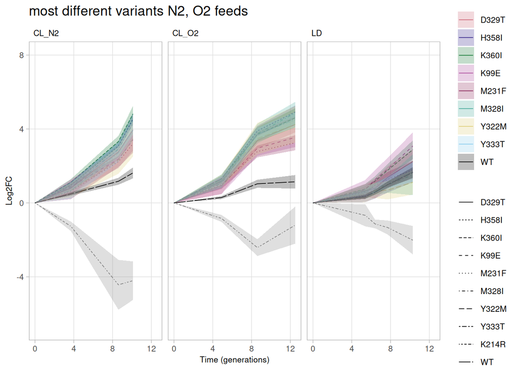

```r
possibly_specific_variants <- c("H358I", "K360I", "M328I", "Y333T", "H358Q", "Y322M", "D329T", "Y333V", "K99E", "M231F", "Y333I", "WT", neg_control_K214)
possibly_specific_variants <- c("H358I", "K360I", "M328I", "Y333T", "Y322M", "D329T", "K99E", "M231F", "WT", neg_control_K214)
different_colors_set <- c("H358I"="#332288ff", "K360I"="#117733ff", "M328I"="#44aa99ff", "Y333T"="#88cceeff", "Y322M"="#ddcc77ff", "D329T"="#cc6677ff", "K99E"="#aa4499ff", "M231F"="#882255ff", "WT"="black", neg_control_K214="darkgray")
possibly_specific_subset <- unique(subset(fitness_data, fitness_data$sgRNA_target %in% possibly_specific_variants))
possibly_specific_subset$sgRNA_target <- factor(possibly_specific_subset$sgRNA_target, levels=c(unique(subset(possibly_specific_subset, !possibly_specific_subset$sgRNA_target %in% c(neg_control_K214, "WT"))$sgRNA_target), neg_control_K214, "WT"))
p <- lineplot_CVinterval_severalColours_meanlog2(possibly_specific_subset) + labs(title="most different variants N2, O2 feeds") + scale_color_manual(values=different_colors_set) + scale_fill_manual(values=different_colors_set) #+ scale_linetype_manual(values=c("WT"="solid", possibly_specific_variants[9]=44, possibly_specific_variants[1]=88, possibly_specific_variants[2]=13, possibly_specific_variants[3]=1343, possibly_specific_variants[4]=131343, possibly_specific_variants[5]=73, possibly_specific_variants[6]=2262, possibly_specific_variants[7]=112233, possibly_specific_variants[8]=11223344))
p
```

```r
ggsave("../lfcSE_weighted_outputImages/pdf/mostDifferent_CLN2_CLO2_timeLinePlot.pdf", plot=p, width=10, height=10)
ggsave("../lfcSE_weighted_outputImages/png/mostDifferent_CLN2_CLO2_variants_timeLinePlot.png", plot=p, width=10, height=10)
a <- pivot_wider(unique(subset(fitness_data, fitness_data$sgRNA_target %in% possibly_specific_variants)[,c("sgRNA_target", "condition", "norm", "p_fit_adj_WT", "num_barcodes")]), values_from=c("norm", "p_fit_adj_WT"), names_from=condition)
a$norm_multiply <- a$norm_CL_N2 * a$norm_CL_O2 * a$norm_LD
a[order(a$norm_multiply, decreasing = TRUE),]
```

| sgRNA_target | num_barcodes | norm_CL_N2 | norm_CL_O2 | norm_LD | p_fit_adj_WT_CL_N2 | p_fit_adj_WT_CL_O2 | p_fit_adj_WT_LD | norm_multiply |
| --- | --- | --- | --- | --- | --- | --- | --- | --- |
| K360I | 14 | 1.399794 | 1.98169832 | 1.37744505 | 4.582160e-08 | 1.715643e-07 | 8.573945e-05 | 3.820990 |
| K99E | 11 | 1.229314 | 1.68134984 | 1.40367846 | 2.799129e-04 | 2.402862e-05 | 5.223860e-02 | 2.901273 |
| D329T | 15 | 1.275003 | 1.82220808 | 1.20817193 | 1.386553e-04 | 2.527961e-05 | 1.156080e-01 | 2.806971 |
| H358I | 11 | 1.345127 | 2.04285267 | 1.00940447 | 2.681402e-07 | 1.532124e-06 | 1.000000e+00 | 2.773738 |
| Y333T | 9 | 1.251135 | 1.94980821 | 1.10392778 | 1.812219e-03 | 9.056318e-06 | 3.007094e-01 | 2.693002 |
| M328I | 10 | 1.307708 | 1.96487715 | 1.03658142 | 2.660031e-04 | 6.305607e-06 | 9.040261e-01 | 2.663482 |
| M231F | 9 | 1.174433 | 1.63762180 | 1.14499054 | 9.621050e-03 | 2.527961e-05 | 5.016551e-02 | 2.202134 |
| Y322M | 11 | 1.197688 | 1.88832050 | 0.94843063 | 2.339531e-01 | 5.144283e-04 | 3.788934e-01 | 2.144989 |
| WT | 30 | 1.000000 | 1.00000000 | 1.00000000 | 1.000000e+00 | 1.000000e+00 | 1.000000e+00 | 1.000000 |
| K214R | 5 | 0.000000 | -0.04337233 | -0.06588767 | 7.491607e-05 | 7.054395e-05 | 8.573945e-05 | 0.000000 |

## Compare light-dark and continuous light at the same gas feed

```r
lm_CLO2_LD <- lm(norm_LD ~ norm_CL_O2, wide_fitness)
summary(lm_CLO2_LD)
```

```
##
## Call:
## lm(formula = norm_LD ~ norm_CL_O2, data = wide_fitness)
##
## Residuals:
##      Min       1Q   Median       3Q      Max
## -1.24578 -0.09276  0.00288  0.09357  1.31207
##
## Coefficients:
##             Estimate Std. Error t value Pr(>|t|)
## (Intercept) 0.143199   0.001874   76.41   <2e-16 ***
## norm_CL_O2  0.607644   0.003211  189.25   <2e-16 ***
## ---
## Signif. codes:  0 '***' 0.001 '**' 0.01 '*' 0.05 '.' 0.1 ' ' 1
##
## Residual standard error: 0.159 on 13964 degrees of freedom
## Multiple R-squared:  0.7195, Adjusted R-squared:  0.7195
## F-statistic: 3.582e+04 on 1 and 13964 DF,  p-value: < 2.2e-16
```

```r
correlation <- cor.test(wide_fitness$norm_CL_O2, wide_fitness$norm_LD, method = 'spearman')
correlation
```

```
##
##  Spearman's rank correlation rho
##
## data:  wide_fitness$norm_CL_O2 and wide_fitness$norm_LD
## S = 7.9154e+10, p-value < 2.2e-16
## alternative hypothesis: true rho is not equal to 0
## sample estimates:
##       rho
## 0.8256552
```

```r
correlation <- cor.test(wide_fitness$norm_CL_O2, wide_fitness$norm_LD, method = 'pearson')
correlation
```

```
##
##  Pearson's product-moment correlation
##
## data:  wide_fitness$norm_CL_O2 and wide_fitness$norm_LD
## t = 189.25, df = 13964, p-value < 2.2e-16
## alternative hypothesis: true correlation is not equal to 0
## 95 percent confidence interval:
##  0.8435058 0.8528124
## sample estimates:
##       cor
## 0.8482246
```

```r
CL_LD_cutoff <- 0.32
barcode_cutoff <- 2
adjp_cutoff <- 0.05

wide_fitness_LD_OL <- wide_fitness

wide_fitness_LD_OL$distance_lm <- wide_fitness_LD_OL$norm_LD - (lm_CLO2_LD$coefficients[1] + lm_CLO2_LD$coefficients[2] * wide_fitness_LD_OL$norm_CL_O2)
wide_fitness_LD_OL[order(wide_fitness_LD_OL$distance_lm, decreasing = TRUE),][1:10,]
```

| sgRNA_target | num_barcodes | category | norm_CL_N2 | norm_CL_O2 | norm_LD | p_fit_adj_WT_CL_N2 | p_fit_adj_WT_CL_O2 | p_fit_adj_WT_LD | WT_not_WT | distance_lm |
| --- | --- | --- | --- | --- | --- | --- | --- | --- | --- | --- |
| A244D | 1 | saturational | 0.9264494 | 0.8024343 | 1.9428648 | 0.35889552 | 0.151178951 | 0.07993531 | notWT | 1.3120717 |
| H141V,K261E,H265A,Q406E,S446T | 1 | combinatorial | 1.3720001 | 1.5201042 | 2.0440550 | 0.08023996 | 0.151178951 | 0.07993531 | notWT | 0.9771741 |
| M154E,H265A,Q406D,S446T | 1 | combinatorial | 1.5106121 | 1.5697215 | 2.0380578 | 0.08023996 | 0.151178951 | 0.07993531 | notWT | 0.9410272 |
| A275N | 1 | saturational | 0.7970074 | 0.2393631 | 1.2273005 | 0.15226111 | 0.078472990 | 0.35594837 | notWT | 0.9386543 |
| H265E,V337S,Q406E,S446I | 1 | combinatorial | 0.6443200 | -0.1130142 | 0.9528273 | 0.08023996 | 0.078472990 | 0.85586389 | notWT | 0.8783012 |
| V98T | 1 | saturational | 1.1609164 | 0.9945623 | 1.5803221 | 0.22288974 | 0.918388215 | 0.07993531 | notWT | 0.8327836 |
| K479V | 2 | saturational | 1.0489432 | 0.9870737 | 1.5616449 | 0.48083526 | 0.920848652 | 0.07240631 | notWT | 0.8186568 |
| K276Q | 2 | saturational | 0.8113293 | 0.4561622 | 1.2284031 | 0.02520757 | 0.006702476 | 0.22454165 | notWT | 0.8080203 |
| K33L | 2 | saturational | 1.1600161 | 0.9193161 | 1.4844833 | 0.08023996 | 0.612716960 | 0.28900659 | notWT | 0.7826677 |
| A275E | 2 | saturational | 0.8601797 | 0.5897253 | 1.2690465 | 0.03714339 | 0.438341362 | 0.52375245 | notWT | 0.7675049 |

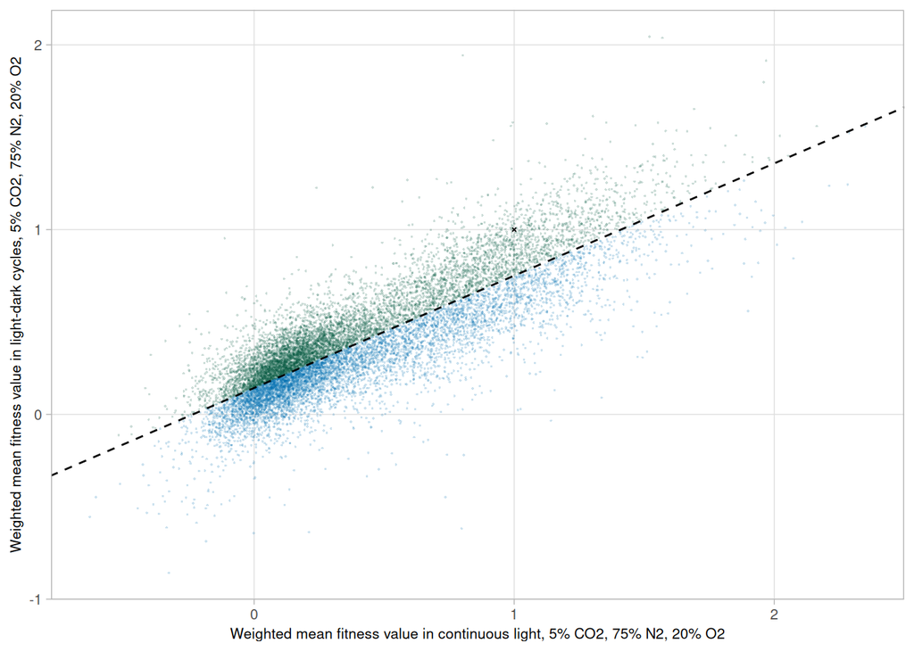

```r
# coloring according to differential expression
wide_fitness_LD_OL$diff <- "NO"
wide_fitness_LD_OL$diff[wide_fitness_LD_OL$distance_lm > 0] <- "LD"
wide_fitness_LD_OL$diff[wide_fitness_LD_OL$distance_lm < 0] <- "CL_O2"
#wide_fitness_LD_OL$diff[wide_fitness_LD_OL$distance_lm > CL_LD_cutoff] <- "LD" # if using cut-off
#wide_fitness_LD_OL$diff[wide_fitness_LD_OL$distance_lm < (-CL_LD_cutoff)] <- "CL_O2" # if using cut-off
wide_fitness_LD_OL[wide_fitness_LD_OL$sgRNA_target=="WT",]$diff <- "WT"

p <- ggplot(wide_fitness_LD_OL, aes(x=norm_CL_O2, y=norm_LD, color=diff, shape=WT_not_WT)) + geom_point(aes(size=WT_not_WT, alpha=WT_not_WT), show.legend=FALSE) + scale_shape_manual(values=WT_shape) + scale_size_manual(values=WT_size) + scale_alpha_manual(values=WT_alpha) + theme_light() + labs(y="Weighted mean fitness value in light-dark cycles, 5% CO2, 75% N2, 20% O2", x="Weighted mean fitness value in continuous light, 5% CO2, 75% N2, 20% O2") + theme(legend.position = "none", panel.grid.minor = element_blank()) + geom_abline(intercept=lm_CLO2_LD$coefficients[1],slope=lm_CLO2_LD$coefficients[2],linetype="dashed",color="black")+ scale_colour_manual(values = dotplot_colors) + theme(panel.grid.minor = element_blank(), strip.background=element_rect(fill = NA, color = "white"), strip.text.x = element_text(size = 8, colour = "black", hjust = 0), axis.text=element_text(size=8), axis.title=element_text(size=8), legend.text=element_text(size=8)) #+ xlim(-6, +7) +ylim(-6,+7)  + geom_abline(intercept=lm_CLO2_LD$coefficients[1]-CL_LD_cutoff, slope=lm_CLO2_LD$coefficients[2], linetype="dashed", color="black") + geom_abline(intercept=lm_CLO2_LD$coefficients[1]+CL_LD_cutoff, slope=lm_CLO2_LD$coefficients[2], linetype="dashed", color="black")
ggsave(filename = "../lfcSE_weighted_outputImages/pdf/wfitness_CLO2_LD_withoutSignif_withoutLabeling.pdf", plot=p, width=4, height=4, units="cm")
ggsave(filename = "../lfcSE_weighted_outputImages/png/wfitness_CLO2_LD_withoutSignif_withoutLabeling.png", plot=p, width=4, height=4, units="cm")
p
```

Run Wilcoxon test to check for significant differences between conditions.

```r
subset_signif_highLD <- subset(subset_signif_highLD, subset_signif_highLD$condition %in% c("LD", "CL_O2") & subset_signif_highLD$time==0.0)

get_controls <- function(cond_spec, sgRNA_spec){
  control_table <- subset_signif_highLD[subset_signif_highLD$condition != unique(cond_spec) & subset_signif_highLD$sgRNA_target == unique(sgRNA_spec) & subset_signif_highLD$time == 0,]
  control_table$fitness
}

subset_signif_highLD <- dplyr::left_join(
  subset_signif_highLD,
  subset_signif_highLD %>%
    dplyr::group_by(sgRNA_target, condition, time) %>%
    dplyr::summarize(
      .groups = "keep",
      # apply Wilcoxon rank sum test against other condition
      p_fitness_condition = stats::wilcox.test(
        x = fitness,
        y = get_controls(condition, sgRNA_target),
        paired = TRUE,
        alternative = "two.sided"
        )$p.value
      ),
  by = c("sgRNA_target", "condition", "time")
  )

subset_signif_highLD <- subset_signif_highLD %>%
  group_by(condition, time) %>%
  mutate(
    p_fitness_condition_adj = stats::p.adjust(p_fitness_condition, method = "BH")
    )
```

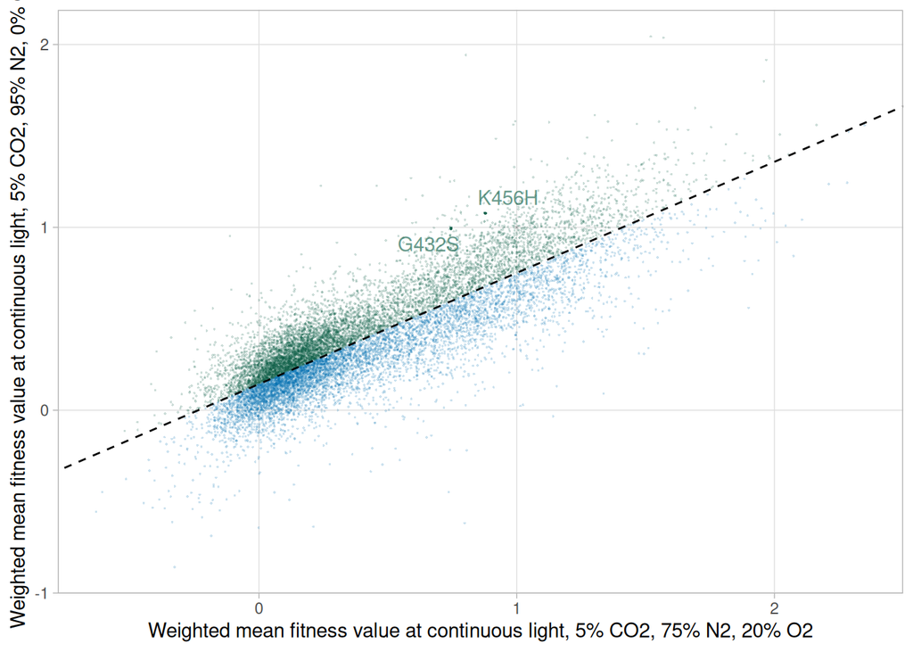

```r
subset_signif_highLD_red <- unique(subset_signif_highLD[,c("sgRNA_target", "norm", "condition", "num_barcodes", "p_fitness_condition_adj")])
subset_signif_highLD_red <- pivot_wider(subset_signif_highLD_red, values_from =c(norm,p_fitness_condition_adj), names_from=condition)

# labels, alpha and size according to significance
wide_fitness_LD_OL$signif <- "NO"
wide_fitness_LD_OL$signif[wide_fitness_LD_OL$sgRNA_target %in% unique(subset(subset_signif_highLD, subset_signif_highLD$p_fitness_condition_adj < 0.4))$sgRNA_target] <- "SIG"
wide_fitness_LD_OL$delabel <- NA
wide_fitness_LD_OL$delabel[wide_fitness_LD_OL$signif =="SIG"] <- as.character(wide_fitness_LD_OL$sgRNA_target[wide_fitness_LD_OL$signif =="SIG"])
wide_fitness_CL_OL[wide_fitness_CL_OL$sgRNA_target=="WT",]$signif <- "WT" # to ensure WT is visible

p <- ggplot(wide_fitness_LD_OL, aes(x=norm_CL_O2, y=norm_LD, color=diff, label=delabel, shape=WT_not_WT)) + scale_shape_manual(values=WT_shape) + geom_point(aes(size=signif, alpha=signif), show.legend=FALSE) + scale_size_manual(values=signif_size) + scale_alpha_manual(values=signif_alpha) + theme_light() + labs(y="Weighted mean fitness value at continuous light, 5% CO2, 95% N2, 0% O2", x="Weighted mean fitness value at continuous light, 5% CO2, 75% N2, 20% O2") + theme(legend.position = "none", panel.grid.minor = element_blank()) + geom_abline(intercept=lm_CLO2_LD$coefficients[1],slope=lm_CLO2_LD$coefficients[2],linetype="dashed",color="black") + scale_colour_manual(values = dotplot_colors) + geom_text_repel() #+ xlim(0.75, 2.5) +ylim(0.75,2.25)
p
```

```r
ggsave(filename = "../lfcSE_weighted_outputImages/pdf/wfitness_LD_CLO2_Wilcox_signif.pdf", plot=p, width=12.5, height=12.5, units="cm")
ggsave(filename = "../lfcSE_weighted_outputImages/png/wfitness_LD_CLO2_Wilcox_signif.png", plot=p, width=12.5, height=12.5, units="cm")
wide_fitness_CL_OL[wide_fitness_LD_OL$signif=="SIG",][order(wide_fitness_LD_OL[wide_fitness_LD_OL$signif=="SIG",]$norm_LD, decreasing=TRUE),]
```

| sgRNA_target | num_barcodes | category | norm_CL_N2 | norm_CL_O2 | norm_LD | p_fit_adj_WT_CL_N2 | p_fit_adj_WT_CL_O2 | p_fit_adj_WT_LD | WT_not_WT | distance_lm | diff | delabel | signif |
| --- | --- | --- | --- | --- | --- | --- | --- | --- | --- | --- | --- | --- | --- |
| K456H | 8 | saturational | 0.9538061 | 0.8780783 | 1.0776249 | 0.199119319 | 0.0784729899 | 0.3653595 | notWT | 0.11339890 | CL_N2 | NA | NO |
| G432S | 10 | saturational | 0.8461023 | 0.7454447 | 0.9944337 | 0.001826114 | 0.0006170594 | 0.9249816 | notWT | 0.09242953 | CL_N2 | NA | NO |

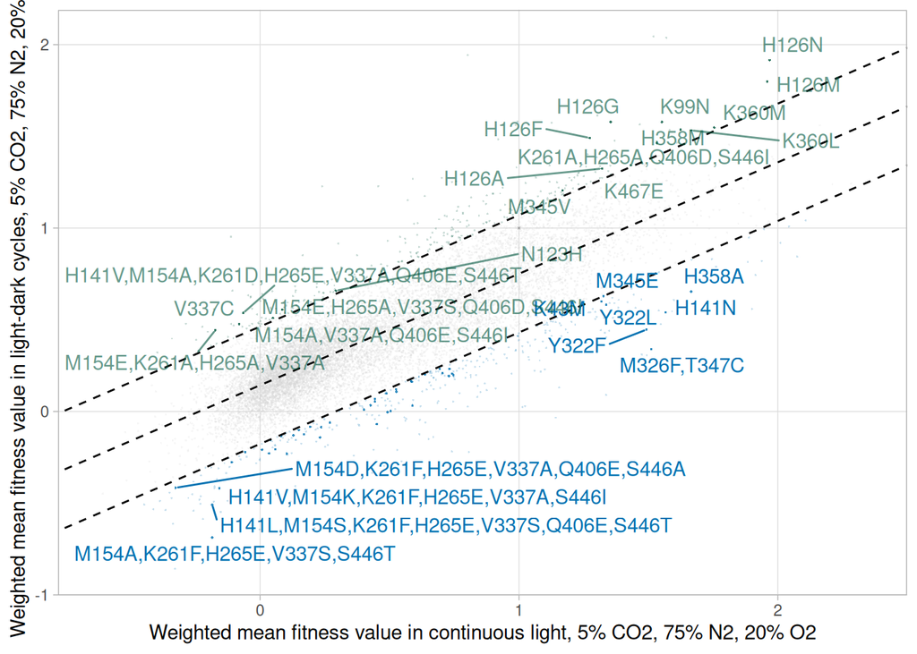

```r
## coloring according to differential expression
wide_fitness_LD_OL$diff <- "NO"
wide_fitness_LD_OL$diff[wide_fitness_LD_OL$distance_lm > CL_LD_cutoff] <- "LD" # if using cut-off
wide_fitness_LD_OL$diff[wide_fitness_LD_OL$distance_lm < (-CL_LD_cutoff)] <- "CL_O2" # if using cut-off
wide_fitness_LD_OL[wide_fitness_LD_OL$sgRNA_target=="WT",]$diff <- "WT"

# labels, alpha and size according to significant difference to WT variant
wide_fitness_LD_OL$signif <- "NO"
wide_fitness_LD_OL$signif[wide_fitness_LD_OL$p_fit_adj_WT_CL_O2 < adjp_cutoff & wide_fitness_LD_OL$p_fit_adj_WT_LD < adjp_cutoff & (wide_fitness_LD_OL$diff=="LD" | wide_fitness_LD_OL$diff=="CL_O2") & wide_fitness_LD_OL$num_barcodes >= barcode_cutoff] <- "SIG"
signif_size <- c("NO"=0.2, "SIG"=0.3)
signif_alpha <- c("NO"=0.2, "SIG"=0.8)
wide_fitness_LD_OL$delabel <- as.character(wide_fitness_LD_OL$sgRNA_target)
wide_fitness_LD_OL$delabel[wide_fitness_LD_OL$signif !="SIG"] <- NA

p <- ggplot(wide_fitness_LD_OL, aes(x=norm_CL_O2, y=norm_LD, color=diff, shape=WT_not_WT, label=delabel)) + geom_point(aes(size=signif, alpha=signif), show.legend=FALSE) + scale_shape_manual(values=WT_shape) + scale_size_manual(values=signif_size) + scale_alpha_manual(values=signif_alpha) + theme_light() + labs(y="Weighted mean fitness value in light-dark cycles, 5% CO2, 75% N2, 20% O2", x="Weighted mean fitness value in continuous light, 5% CO2, 75% N2, 20% O2") + theme(legend.position = "none", panel.grid.minor = element_blank()) + geom_abline(intercept=lm_CLO2_LD$coefficients[1],slope=lm_CLO2_LD$coefficients[2],linetype="dashed",color="black")+ scale_colour_manual(values = dotplot_colors)  + geom_abline(intercept=lm_CLO2_LD$coefficients[1]-CL_LD_cutoff, slope=lm_CLO2_LD$coefficients[2], linetype="dashed", color="black") + geom_abline(intercept=lm_CLO2_LD$coefficients[1]+CL_LD_cutoff, slope=lm_CLO2_LD$coefficients[2], linetype="dashed", color="black") + geom_text_repel() #  + xlim(-6, +7) +ylim(-6,+7)
ggsave(filename = "../lfcSE_weighted_outputImages/pdf/wfitness_CLO2_LD_attempt_findDifferentVariants.pdf", plot=p, width=12.5, height=12.5, units="cm")
ggsave(filename = "../lfcSE_weighted_outputImages/png/wfitness_CLO2_LD_attempt_findDifferentVariants.png", plot=p, width=12.5, height=12.5, units="cm")
p
```

```r
wide_fitness_LD_OL_sig <- subset(wide_fitness_LD_OL, wide_fitness_LD_OL$signif=="SIG")
wide_fitness_LD_OL_sig[order(wide_fitness_LD_OL_sig$distance_lm, decreasing = TRUE),][1:10,]
```

| sgRNA_target | num_barcodes | category | norm_CL_N2 | norm_CL_O2 | norm_LD | p_fit_adj_WT_CL_N2 | p_fit_adj_WT_CL_O2 | p_fit_adj_WT_LD | WT_not_WT | distance_lm | diff | signif | delabel |
| --- | --- | --- | --- | --- | --- | --- | --- | --- | --- | --- | --- | --- | --- |
| H126G | 8 | saturational | 1.1677323 | 1.35422580 | 1.5786436 | 0.0002375482 | 6.702476e-03 | 4.808540e-06 | notWT | 0.6125577 | LD | SIG | H126G |
| H126N | 2 | saturational | 1.2314739 | 1.96825327 | 1.9150875 | 0.0252075737 | 2.537248e-02 | 7.021051e-03 | notWT | 0.5758915 | LD | SIG | H126N |
| H126F | 7 | saturational | 1.0435614 | 1.27277015 | 1.4916584 | 0.2936334569 | 3.985546e-02 | 8.573945e-05 | notWT | 0.5750686 | LD | SIG | H126F |
| K99N | 4 | saturational | 1.1999512 | 1.55238439 | 1.5780889 | 0.0204096014 | 8.601813e-03 | 1.554763e-03 | notWT | 0.4915932 | LD | SIG | K99N |
| H126M | 7 | saturational | 1.2299685 | 1.95929076 | 1.7983289 | 0.0084859016 | 7.054395e-05 | 1.209730e-04 | notWT | 0.4645789 | LD | SIG | H126M |
| H141V,M154A,K261D,H265E,V337A,Q406E,S446T | 2 | combinatorial | 0.3479108 | -0.06463953 | 0.5376317 | 0.0068502335 | 6.702476e-03 | 2.551430e-02 | notWT | 0.4337110 | LD | SIG | H141V,M154A,K261D,H265E,V337A,Q406E,S446T |
| H358M | 2 | saturational | 1.1358688 | 1.62400889 | 1.5369418 | 0.0802399597 | 2.537248e-02 | 7.021051e-03 | notWT | 0.4069238 | LD | SIG | H358M |
| M154E,K261A,H265A,V337A | 2 | combinatorial | 0.3045451 | -0.17352924 | 0.4422978 | 0.0068502335 | 6.702476e-03 | 7.021051e-03 | notWT | 0.4045433 | LD | SIG | M154E,K261A,H265A,V337A |
| L132M | 2 | saturational | 1.1941469 | 1.53280229 | 1.4636023 | 0.0721127612 | 2.537248e-02 | 7.021051e-03 | notWT | 0.3890055 | LD | SIG | L132M |
| V337C | 2 | saturational | 0.5467428 | -0.08143607 | 0.4762844 | 0.0068502335 | 6.702476e-03 | 7.021051e-03 | notWT | 0.3825700 | LD | SIG | V337C |

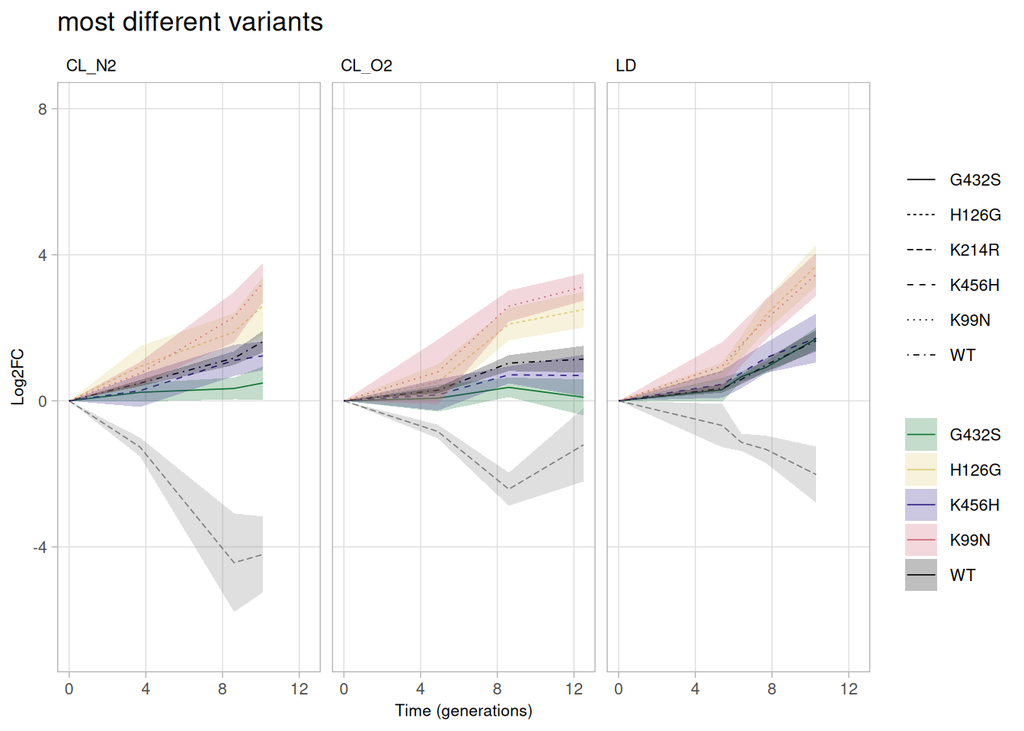

```r
possibly_higher_inLD <- c("K456H", "G432S", "K99N", "H126G","WT", neg_control_K214)
different_colors_set <- c("K456H"="#332288ff", "G432S"="#117733ff", "H358M"="#44aa99ff", "H126N"="#88cceeff", "H126G"="#ddcc77ff", "K99N"="#cc6677ff", "WT"="black", neg_control_K214="darkgray")
single_subset <- subset(fitness_data, fitness_data$sgRNA_target %in% possibly_higher_inLD)
p <- lineplot_CVinterval_severalColours_meanlog2(single_subset) + labs(title="most different variants") + scale_color_manual(values=different_colors_set) + scale_fill_manual(values=different_colors_set)
p
```

```r
ggsave("../lfcSE_weighted_outputImages/pdf/mostDifferent_LD_CLO2_timeLinePlot.pdf", plot=p, width=10, height=10)
ggsave("../lfcSE_weighted_outputImages/png/mostDifferent_LD_CLO2_variants_timeLinePlot.png", plot=p, width=10, height=10)

unique(subset(fitness_data, fitness_data$sgRNA_target %in% possibly_higher_inLD)[,c("sgRNA_target", "condition", "norm", "p_fit_adj_WT", "num_barcodes")])
```

| sgRNA_target | condition | norm | p_fit_adj_WT | num_barcodes |
| --- | --- | --- | --- | --- |
| G432S | CL_N2 | 0.84610233 | 1.826114e-03 | 10 |
| G432S | CL_O2 | 0.74544470 | 6.170594e-04 | 10 |
| G432S | LD | 0.99443371 | 9.249816e-01 | 10 |
| H126G | CL_N2 | 1.16773233 | 2.375482e-04 | 8 |
| H126G | CL_O2 | 1.35422580 | 6.702476e-03 | 8 |
| H126G | LD | 1.57864358 | 4.808540e-06 | 8 |
| K214R | CL_N2 | 0.00000000 | 7.491607e-05 | 5 |
| K214R | CL_O2 | -0.04337233 | 7.054395e-05 | 5 |
| K214R | LD | -0.06588767 | 8.573945e-05 | 5 |
| K456H | CL_N2 | 0.95380614 | 1.991193e-01 | 8 |

[output cut: 8 more lines]

# Generally interesting mutants

In the following, an attempt is made to pinpoint some interesting variants that are worth testing. The following chunk of code selects all variants which are performing well under all conditions and are significantly different to the base variant. Furthermore, only variants with at least two barcodes are taken into account.

```r
columns <- c("sgRNA_target",  "condition", "norm", "p_fit_adj_WT", "num_barcodes", "number_muts")
fitness_data_goodVariants <- pivot_wider(unique(fitness_data[,columns]), values_from = c("norm", "p_fit_adj_WT"), names_from = condition)
fitness_data_goodVariants <- unique(subset(fitness_data_goodVariants, fitness_data_goodVariants$p_fit_adj_WT_CL_N2 < 0.05 & fitness_data_goodVariants$p_fit_adj_WT_CL_O2 < 0.05 & fitness_data_goodVariants$p_fit_adj_WT_LD < 0.05 & fitness_data_goodVariants$norm_CL_N2 > 1 & fitness_data_goodVariants$norm_CL_O2 > 1 & fitness_data_goodVariants$norm_LD > 1 & fitness_data_goodVariants$num_barcodes > 1))

length(unique(fitness_data_goodVariants$sgRNA_target))
```

```
## [1] 23
```

```r
length(unique(fitness_data_goodVariants$sgRNA_target))/length(unique(fitness_data$sgRNA_target))
```

```
## [1] 0.001646857
```

```r
fitness_data_goodVariants$combined_norms <- fitness_data_goodVariants$norm_CL_N2 * fitness_data_goodVariants$norm_CL_O2 * fitness_data_goodVariants$norm_LD
print(fitness_data_goodVariants[order(fitness_data_goodVariants$combined_norms, decreasing = TRUE),])
```

```
## # A tibble: 23 × 10
##    sgRNA_target num_barcodes number_muts norm_CL_N2 norm_CL_O2 norm_LD
##    <chr>               <dbl>       <dbl>      <dbl>      <dbl>   <dbl>
##  1 H126N                   2           1       1.23       1.97    1.92
##  2 H126M                   7           1       1.23       1.96    1.80
##  3 W128I                   6           1       1.42       1.98    1.39
##  4 K360I                  14           1       1.40       1.98    1.38
##  5 K360M                   8           1       1.30       1.75    1.55
##  6 Q142D                   4           1       1.29       1.89    1.41
##  7 K233C                   5           1       1.22       1.81    1.45
##  8 H358C                  12           1       1.29       1.91    1.30
##  9 K360L                   2           1       1.23       1.67    1.53
## 10 H358L                  12           1       1.31       1.88    1.26
## # ℹ 13 more rows
## # ℹ 4 more variables: p_fit_adj_WT_CL_N2 <dbl>, p_fit_adj_WT_CL_O2 <dbl>,
## #   p_fit_adj_WT_LD <dbl>, combined_norms <dbl>
```

```r
write_csv(fitness_data_goodVariants[order(fitness_data_goodVariants$combined_norms, decreasing = TRUE),], "../lfcSE_weighted_outputImages/goodVariants.csv")
```

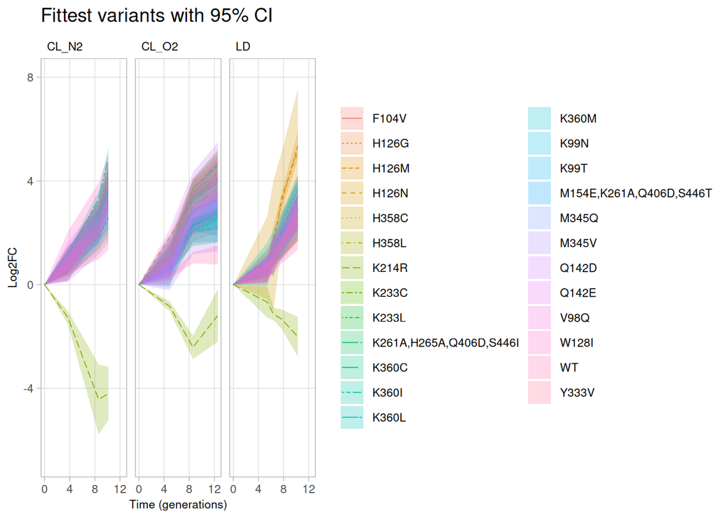

```r
highScoring_subset <- subset(fitness_data, fitness_data$sgRNA_target %in% c("H126N", "H126M", "W128I", "K360I", "K360M", "Q142D", "K233C", "H358C", "K360L", "H358L", "K99N", "K360C", "Y333V", "H126G", "M154E,K261A,Q406D,S446T", "Q142E", "M345Q", "F104V", "V98Q", "K261A,H265A,Q406D,S446I", "K99T", "K233L", "M345V", "WT", neg_control_K214))
p <- lineplot_CVinterval_severalColours_meanlog2(highScoring_subset) + labs(title="Fittest variants with 95% CI")
p
```

```r
ggsave("../lfcSE_weighted_outputImages/pdf/highest_variants_timeLinePlot.pdf", plot=p)
ggsave("../lfcSE_weighted_outputImages/png/highest_variants_timeLinePlot.png", plot=p)
```

Partially, exchanges at the same amino acid position score quite similarly. We cannot distinguish their fitness on basis of our data.

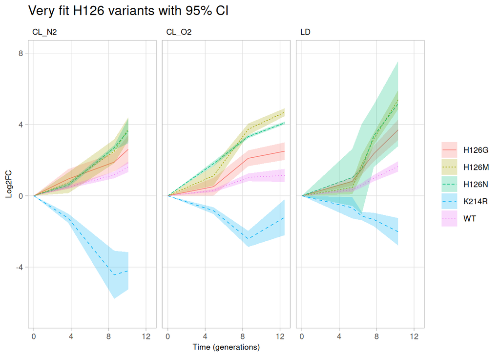

```r
plot_subset <- subset(fitness_data, fitness_data$sgRNA_target %in% c("H126N", "H126M", "H126G", "WT", neg_control_K214))
p <- lineplot_CVinterval_severalColours_meanlog2(plot_subset) + labs(title="Very fit H126 variants with 95% CI")
p
```

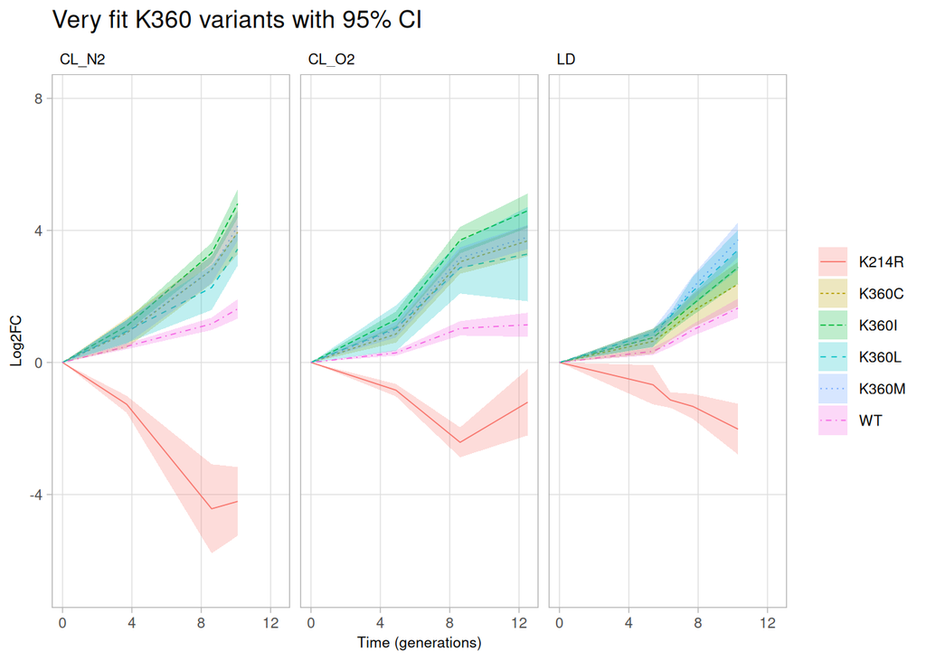

```r
ggsave("../lfcSE_weighted_outputImages/pdf/H126_subset_variants_timeLinePlot.pdf", plot=p)
ggsave("../lfcSE_weighted_outputImages/png/H126_subset_variants_timeLinePlot.png", plot=p)

plot_subset <- subset(fitness_data, fitness_data$sgRNA_target %in% c("K360I", "K360M", "K360L", "K360C", "WT", neg_control_K214))
p <- lineplot_CVinterval_severalColours_meanlog2(plot_subset) + labs(title="Very fit K360 variants with 95% CI")
p
```

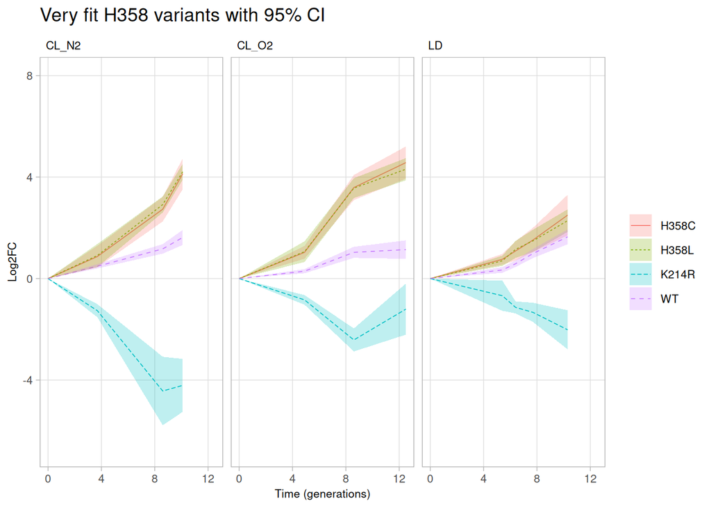

```r
ggsave("../lfcSE_weighted_outputImages/pdf/K360_subset_variants_timeLinePlot.pdf", plot=p)
ggsave("../lfcSE_weighted_outputImages/png/K360_subset_variants_timeLinePlot.png", plot=p)

plot_subset <- subset(fitness_data, fitness_data$sgRNA_target %in% c("H358C", "H358L", "WT", neg_control_K214))
p <- lineplot_CVinterval_severalColours_meanlog2(plot_subset) + labs(title="Very fit H358 variants with 95% CI")
p
```

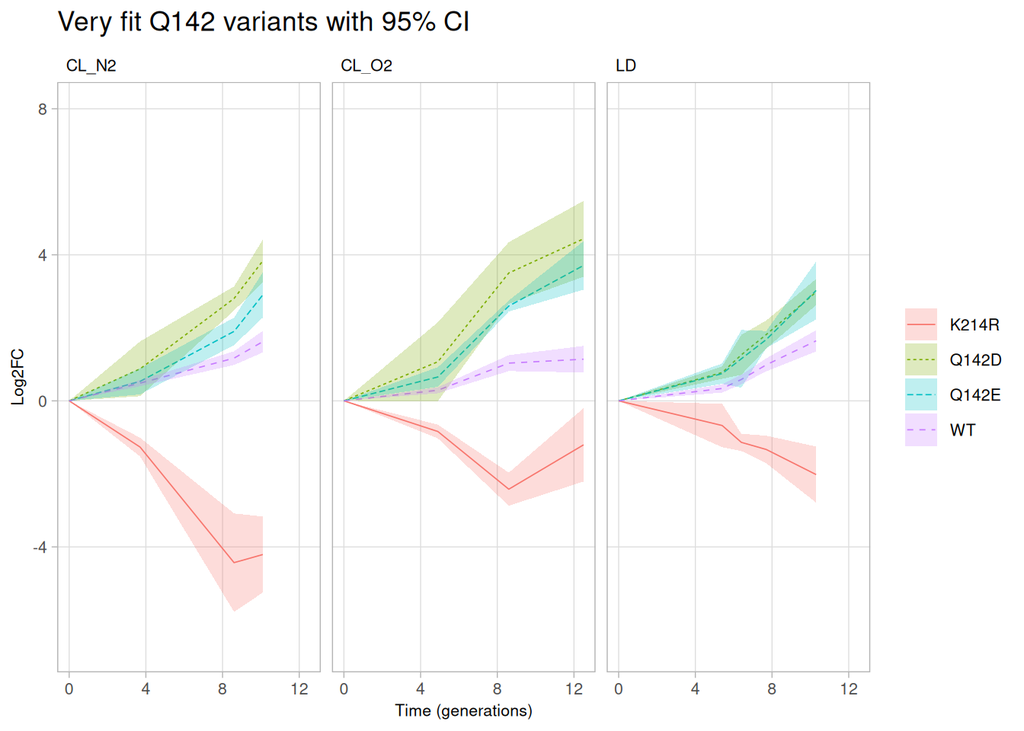

```r
ggsave("../lfcSE_weighted_outputImages/pdf/H358_subset_variants_timeLinePlot.pdf", plot=p)
ggsave("../lfcSE_weighted_outputImages/png/H358_subset_variants_timeLinePlot.png", plot=p)

plot_subset <- subset(fitness_data, fitness_data$sgRNA_target %in% c("Q142D", "Q142E", "WT", neg_control_K214))
p <- lineplot_CVinterval_severalColours_meanlog2(plot_subset) + labs(title="Very fit Q142 variants with 95% CI")
p
```

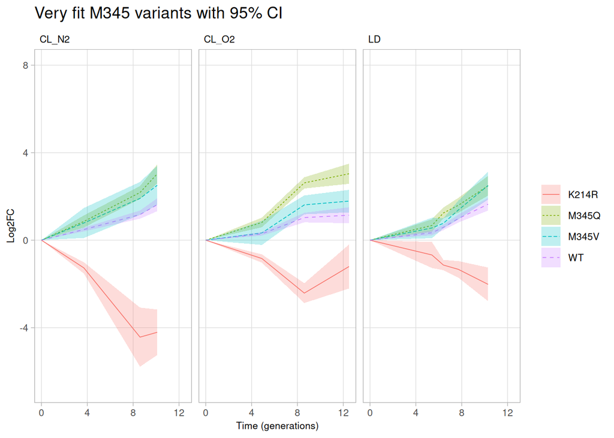

```r
ggsave("../lfcSE_weighted_outputImages/pdf/Q142_subset_variants_timeLinePlot.pdf", plot=p)
ggsave("../lfcSE_weighted_outputImages/png/Q142_subset_variants_timeLinePlot.png", plot=p)

plot_subset <- subset(fitness_data, fitness_data$sgRNA_target %in% c("M345Q", "M345V", "WT", neg_control_K214))
p <- lineplot_CVinterval_severalColours_meanlog2(plot_subset) + labs(title="Very fit M345 variants with 95% CI")
p
```

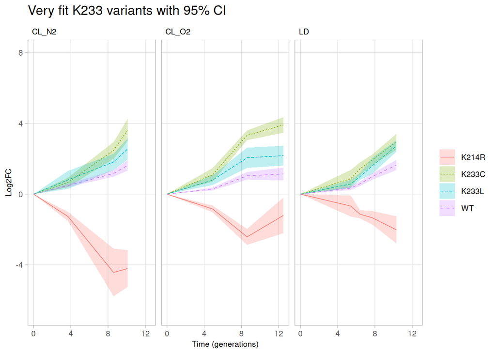

```r
ggsave("../lfcSE_weighted_outputImages/pdf/M345_subset_variants_timeLinePlot.pdf", plot=p)
ggsave("../lfcSE_weighted_outputImages/png/M345_subset_variants_timeLinePlot.png", plot=p)

plot_subset <- subset(fitness_data, fitness_data$sgRNA_target %in% c("K233C", "K233L", "WT", neg_control_K214))
p <- lineplot_CVinterval_severalColours_meanlog2(plot_subset) + labs(title="Very fit K233 variants with 95% CI")
p
```

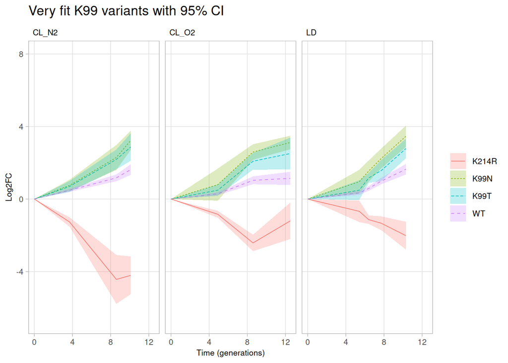

```r
ggsave("../lfcSE_weighted_outputImages/pdf/K233_subset_variants_timeLinePlot.pdf", plot=p)
ggsave("../lfcSE_weighted_outputImages/png/K233_subset_variants_timeLinePlot.png", plot=p)

plot_subset <- subset(fitness_data, fitness_data$sgRNA_target %in% c("K99N", "K99T", "WT", neg_control_K214))
p <- lineplot_CVinterval_severalColours_meanlog2(plot_subset) + labs(title="Very fit K99 variants with 95% CI")
p
```

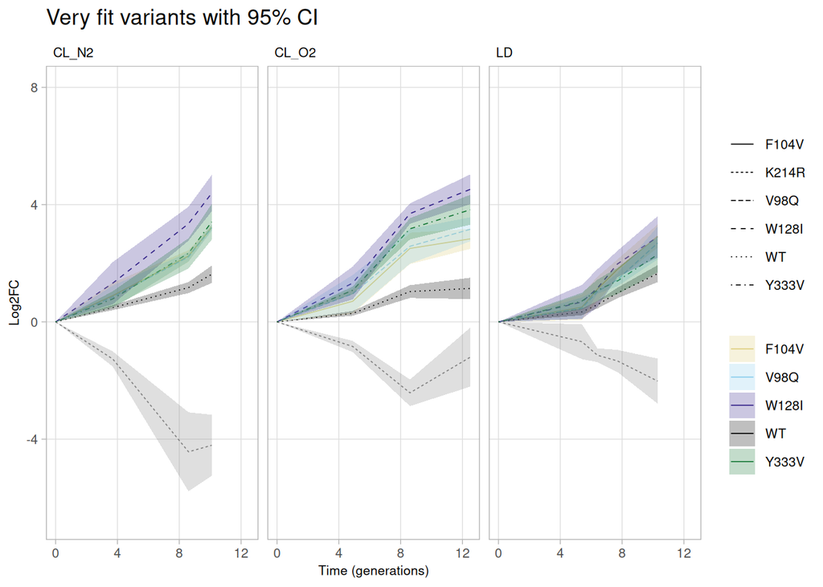

```r
ggsave("../lfcSE_weighted_outputImages/pdf/K99_subset_variants_timeLinePlot.pdf", plot=p)
ggsave("../lfcSE_weighted_outputImages/png/K99_subset_variants_timeLinePlot.png", plot=p)

plot_subset <- subset(fitness_data, fitness_data$sgRNA_target %in% c("W128I", "Y333V", "F104V", "V98Q", "WT", neg_control_K214))
different_colors_set <- c("W128I"="#332288ff", "Y333V"="#117733ff", "V98Q"="#88cceeff", "F104V"="#ddcc77ff", "WT"="black", neg_control_K214="darkgray") #different_colors_set <- c("W128I"="#332288ff", "Y333V"="#117733ff", "F104V"="#44aa99ff", "V98Q"="#88cceeff", "F104V"="#ddcc77ff", "K99N"="#cc6677ff", "WT"="black", neg_control_K214="darkgray")
p <- lineplot_CVinterval_severalColours_meanlog2(plot_subset) + labs(title="Very fit variants with 95% CI") + scale_fill_manual(values=different_colors_set) + scale_color_manual(values=different_colors_set)
p
```

```r
ggsave("../lfcSE_weighted_outputImages/pdf/remaining_highScoring_variants_timeLinePlot.pdf", plot=p)
ggsave("../lfcSE_weighted_outputImages/png/remaining_highScoring_variants_timeLinePlot.png", plot=p)
```

# Plot epistatic effects

## General overview over epistasis in data set

From Miton et al., 2016 (https://onlinelibrary.wiley.com/doi/full/10.1002/pro.2876): “We calculated the fold change in enzyme fitness (F) provided by a mutation i on the wild-type background (ΔFwt,i=Fwt+i/Fwt) and the change caused by the same mutation on the intermediate variant j in the trajectory, (ΔFj,i=Fj+i/Fj) […] epistasis was determined by comparing the fold changes in the trajectory over the wild-type background (ΔFj,i/ΔFwt,i). For the sake of simplicity, we considered that ≥1.5-fold change is significant, and less than 1.5-fold change is neutral (or nearly neutral). […] Neutral designates mutations that show less than 1.5-fold change in enzyme fitness on both backgrounds (0.7 < [ΔFj,i and ΔFwt,i] < 1.5). (ii - v) Functional refers to non-neutral mutations that exhibit >1.5-fold improvement in either genetic background (ΔFj,i or ΔFwt,i > 1.5). Among functional mutations, ii) no epistasis refers to mutations that do not significantly alter the enzyme fitness depending on the background (mutations are additive, ΔFj,i/ΔFwt,i ∼ 1). (iii – iv) Positive epistasis applies to a mutation that becomes more beneficial when combined with prior substitutions on the trajectory, compared to its effect on the wild-type background (ΔFj,i/ΔFwt,i > 1.5). It can be divided in two subclasses: iii) Positive magnitude epistasis refers to cases where the effect is neutral or positive on the wild-type background and is further amplified on the trajectory (ΔFj,i ≫ ΔFwt, i > 0.7 or ΔFj, i ≫ ΔFwt, i > 1.5); and iv) Positive sign epistasis, which refers to mutations causing a deleterious effect on the wild-type background but a beneficial effect on the trajectory (ΔFwt, i <0.7 and ΔFj, i > 1.5). v) Negative epistasis applies to a mutation that becomes less beneficial on the trajectory background compared to its original effect on the wild type (ΔFj, i/ΔFwt, i <0.7).”

Identify cut-off values for good / bad variants - use adj. p values < 0.05 to do so, question “can I significantly distinguish this variant from the base variant?” Seems as if differences as small as a normed value of 1.1 are often already significant compared to the base variant - I assume a normed value of 1.25 is about right.

```r
combinatorial_wide <- subset(combinatorial_wide, combinatorial_wide$p_fit_adj_WT<0.05) # in case things were changed above
a <- unique(subset(combinatorial_wide, combinatorial_wide$norm > 1.0)$norm)
a <- a[order(a)]
a[1:20]
```

```
##  [1] 1.066177 1.077010 1.084487 1.089128 1.089533 1.099646 1.102634 1.103528
##  [9] 1.106683 1.108989 1.109216 1.113865 1.116721 1.118302 1.120763 1.121159
## [17] 1.122081 1.123697 1.124440 1.127339
```

Also, differences as small as 0.9 compared to 1.0 can be distinguished - so I guess a good cut-off might be 0.8.

```r
a <- unique(subset(combinatorial_wide, combinatorial_wide$norm < 1.0)$norm)
a <- a[order(a, decreasing=TRUE)]
a[1:20]
```

```
##  [1] 0.9386771 0.9381779 0.9351133 0.9347565 0.9211815 0.9185717 0.9162180
##  [8] 0.9156449 0.9141355 0.9107536 0.9102129 0.9094565 0.9087976 0.9082542
## [15] 0.9081407 0.9080229 0.9070452 0.9065860 0.9040132 0.9030803
```

```r
summarize_dataframe <- unique(dplyr::summarize(.data=epistatic_table,
      .by = c(Exchange, Condition),
    # value in WT background
    value_background = unique(.data[["Exchange_value_and_ratio_in_WT"]]),
    # number neg. effect in higher order
    number_negative_exchanges = sum(.data[["Variant_ratio"]] < 0.8), # adjusted to 0.8 according to observations detailed above from originally 0.7 in paper
    # number neutral effect in higher order
    number_neutral_exchanges = sum(.data[["Variant_ratio"]] > 0.8 & .data[["Variant_ratio"]] < 1.25), # adjusted to 0.8 and 1.2 from 0.7 and 1.5
    # number pos. effect in higher order
    number_positive_exchanges = sum(.data[["Variant_ratio"]] > 1.25), # adjusted from 1.5 in paper to 1.2 according to observations detailed above
    # no epistasis (0.7 < value < 1.5)
    number_no_epistasis = sum(.data[["ratio_WT_higherOrder"]] > 0.7 & .data[["ratio_WT_higherOrder"]] < 1.5),
    # positive epistasis (>1.5)
    number_positive_epistasis = sum(.data[["ratio_WT_higherOrder"]] > 1.5),
    # negative epistasis (<0.7)
    number_negative_epistasis = sum(.data[["ratio_WT_higherOrder"]] < 0.7),
    # total higher exchange
    number_higher_exchanges = n()
    ))
```

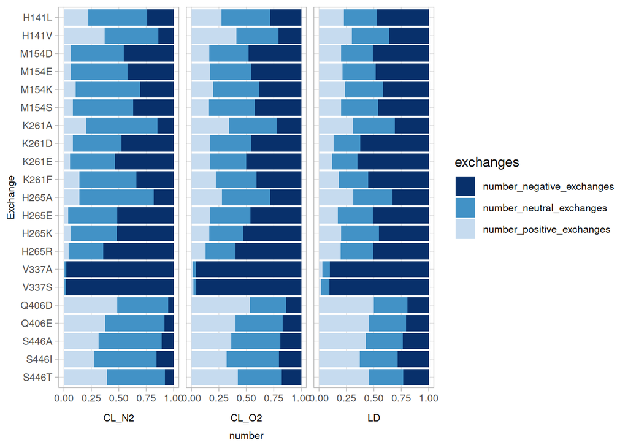

```r
exchanges_dataset <- summarize_dataframe[,c("Exchange", "Condition", "number_negative_exchanges", "number_neutral_exchanges", "number_positive_exchanges")]
exchanges_dataset <- pivot_longer(exchanges_dataset, !c(Exchange, Condition), values_to="number", names_to="exchanges")

exchanges_dataset$Exchange <- factor(exchanges_dataset$Exchange, levels=rev(c("H141L", "H141V", "M154D", "M154E", "M154K", "M154S", "K261A", "K261D", "K261E", "K261F", "H265A", "H265E", "H265K", "H265R", "V337A", "V337S", "Q406D", "Q406E", "S446A", "S446I", "S446T")))

colors_exchanges <- brewer.pal(n = 9, name = "Blues")[c(3,6,9)]
names(colors_exchanges) <- c("number_positive_exchanges", "number_neutral_exchanges", "number_negative_exchanges")

p <- ggplot(exchanges_dataset) +
  geom_bar(aes(x = number, y = Exchange, fill = exchanges),
           position = "fill",
           stat = "identity")  +
  scale_fill_manual(values=colors_exchanges) +
  facet_grid(~ Condition, switch = "x") +
  theme_light() +
  theme(strip.placement = "outside",
        strip.background = element_rect(fill = NA, color = "white"),
        panel.grid.minor = element_blank(),
        axis.text=element_text(size=8),
        axis.title=element_text(size=8),
        legend.text=element_text(size=8),
        strip.text.x = element_text(size = 8, colour = "black"))
p
```

```r
ggsave("../lfcSE_weighted_outputImages/epistasis/Positive_negativeExchanges_higherOrdervariants.pdf", plot=p, width=7.5, height=3)
ggsave("../lfcSE_weighted_outputImages/epistasis/Positive_negativeExchanges_higherOrdervariants.png", plot=p, width=7.5, height=3)
```

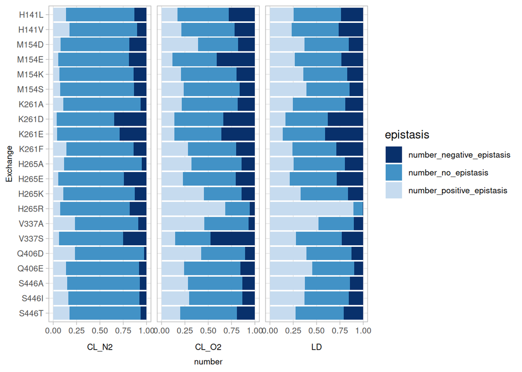

```r
epistasis_dataset <- summarize_dataframe[,c("Exchange", "Condition", "number_no_epistasis", "number_positive_epistasis", "number_negative_epistasis")]
epistasis_dataset <- pivot_longer(epistasis_dataset, !c(Exchange, Condition), values_to="number", names_to="epistasis")

epistasis_dataset$Exchange <- factor(epistasis_dataset$Exchange, levels=rev(c("H141L", "H141V", "M154D", "M154E", "M154K", "M154S", "K261A", "K261D", "K261E", "K261F", "H265A", "H265E", "H265K", "H265R", "V337A", "V337S", "Q406D", "Q406E", "S446A", "S446I", "S446T")))

colors_epistasis <- brewer.pal(n = 9, name = "Blues")[c(3,6,9)]
names(colors_epistasis) <- c("number_positive_epistasis", "number_no_epistasis", "number_negative_epistasis")

p <- ggplot(epistasis_dataset) +
  geom_bar(aes(x = number, y = Exchange, fill = epistasis),
           position = "fill",
           stat = "identity") +
  scale_fill_manual(values=colors_epistasis) +
  facet_grid(~ Condition, switch = "x") +
  theme_light() +
  theme(strip.placement = "outside",
        strip.background = element_rect(fill = NA, color = "white"),
        panel.grid.minor = element_blank(),
        axis.text=element_text(size=8),
        axis.title=element_text(size=8),
        legend.text=element_text(size=8),
        strip.text.x = element_text(size = 8, colour = "black"))
p
```

```r
ggsave("../lfcSE_weighted_outputImages/epistasis/Positive_negativeEpistasis_higherOrdervariants.pdf", plot=p, width=7.5, height=3)
ggsave("../lfcSE_weighted_outputImages/epistasis/Positive_negativeEpistasis_higherOrdervariants.png", plot=p, width=7.5, height=3)
```

## Examples of epistasis

```r
epistatic_table_wide <- pivot_wider(epistatic_table[,c("Condition", "Exchange_value_and_ratio_in_WT", "Exchange", "Variant", "Variant_value", "ratio_WT_higherOrder")], names_from=c("Condition"), values_from=c("Variant_value", "ratio_WT_higherOrder", "Exchange_value_and_ratio_in_WT"))
epistatic_table_wide <- subset(epistatic_table_wide, epistatic_table_wide$ratio_WT_higherOrder_CL_N2>1.5 & epistatic_table_wide$ratio_WT_higherOrder_CL_O2 > 1.5 & epistatic_table_wide$ratio_WT_higherOrder_LD > 1.5 & epistatic_table_wide$Variant_value_CL_N2 > 1.0 & epistatic_table_wide$Variant_value_CL_O2 > 1.0 & epistatic_table_wide$Variant_value_LD > 1.0)
nrow(epistatic_table_wide)
```

```
## [1] 14
```

```r
epistatic_table_wide$ep_product <- epistatic_table_wide$ratio_WT_higherOrder_CL_N2 * epistatic_table_wide$ratio_WT_higherOrder_CL_O2 * epistatic_table_wide$ratio_WT_higherOrder_LD
epistatic_table_wide[order(epistatic_table_wide$ep_product, decreasing=TRUE),]
```

| Exchange | Variant | Variant_value_CL_O2 | Variant_value_CL_N2 | Variant_value_LD | ratio_WT_higherOrder_CL_O2 | ratio_WT_higherOrder_CL_N2 | ratio_WT_higherOrder_LD | Exchange_value_and_ratio_in_WT_CL_O2 | Exchange_value_and_ratio_in_WT_CL_N2 | Exchange_value_and_ratio_in_WT_LD | ep_product |
| --- | --- | --- | --- | --- | --- | --- | --- | --- | --- | --- | --- |
| M154K | M154K,H265E,Q406E,S446T | 1.105911 | 1.072397 | 1.046400 | 13.610044 | 11.394389 | 14.950691 | 0.8125697 | 0.9411624 | 0.6999006 | 2318.525342 |
| K261D | K261D,H265E,Q406E,S446T | 1.212011 | 1.229561 | 1.069277 | 12.895892 | 12.394511 | 14.114769 | 0.9398430 | 0.9920204 | 0.7575592 | 2256.080367 |
| V337A | H141V,M154A,K261F,H265A,V337A,Q406E,S446I | 2.287864 | 1.068219 | 1.522656 | 29.207629 | 4.142314 | 13.263994 | 0.1390793 | 0.3243003 | 0.2491348 | 1604.773278 |
| Q406E | H141V,M154A,K261F,H265A,V337A,Q406E,S446I | 2.287864 | 1.068219 | 1.522656 | 21.253287 | 3.086326 | 16.916939 | 1.0764755 | 1.1207629 | 0.8266148 | 1109.659380 |
| H265A | H141V,M154A,K261F,H265A,V337A,Q406E,S446I | 2.287864 | 1.068219 | 1.522656 | 23.792108 | 2.487756 | 16.784853 | 0.7804592 | 0.8683417 | 0.9071611 | 993.477972 |
| Q406E | H141V,M154A,Q406E | 1.218860 | 1.077284 | 1.082957 | 11.322689 | 9.612059 | 8.738667 | 1.0764755 | 1.1207629 | 0.8266148 | 951.067068 |
| S446I | H141V,M154A,K261F,H265A,V337A,Q406E,S446I | 2.287864 | 1.068219 | 1.522656 | 26.326158 | 2.231721 | 9.454003 | 0.8690460 | 0.9386771 | 0.8405570 | 555.447718 |
| H141V | H141V,M154A,K261F,H265A,V337A,Q406E,S446I | 2.287864 | 1.068219 | 1.522656 | 9.000681 | 2.073163 | 5.227050 | 1.1887371 | 1.0168605 | 0.9639216 | 97.536121 |
| K261F | H141V,M154A,K261F,H265A,V337A,Q406E,S446I | 2.287864 | 1.068219 | 1.522656 | 7.365786 | 2.642448 | 4.445704 | 0.7309233 | 0.8366671 | 0.7295828 | 86.529875 |
| K261A | K261A,H265K,Q406E,S446A | 1.163494 | 1.179298 | 1.195215 | 3.105399 | 1.984844 | 2.522821 | 1.0421205 | 0.9518775 | 0.9172866 | 15.549988 |

[output cut: 4 more lines]

Check again if any of the “good, recovered” strains are just an artefact !

```r
plot_subset <- subset(fitness_data, fitness_data$sgRNA_target %in% c("M154K", "M154K,H265E,Q406E,S446T", "H265E,Q406E,S446T", "WT", neg_control_K214))
unique(plot_subset[,c("sgRNA_target", "norm", "condition", "num_barcodes")])
```

| sgRNA_target | norm | condition | num_barcodes |
| --- | --- | --- | --- |
| H265E,Q406E,S446T | 0.01320950 | CL_N2 | 1 |
| H265E,Q406E,S446T | -0.30354312 | CL_O2 | 1 |
| H265E,Q406E,S446T | -0.19530674 | LD | 1 |
| K214R | 0.00000000 | CL_N2 | 5 |
| K214R | -0.04337233 | CL_O2 | 5 |
| K214R | -0.06588767 | LD | 5 |
| M154K,H265E,Q406E,S446T | 1.07239705 | CL_N2 | 3 |
| M154K,H265E,Q406E,S446T | 1.10591098 | CL_O2 | 3 |
| M154K,H265E,Q406E,S446T | 1.04639975 | LD | 3 |
| M154K | 0.94116242 | CL_N2 | 8 |

[output cut: 5 more lines]

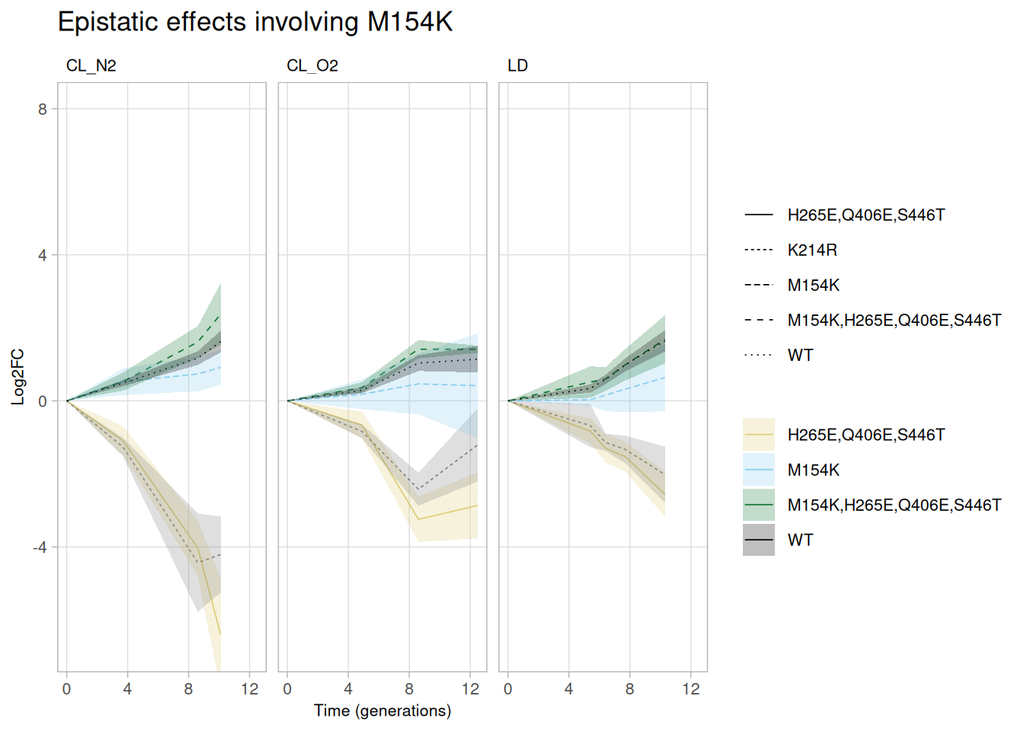

```r
different_colors_set <- c("M154K"="#88cceeff", "M154K,H265E,Q406E,S446T"="#117733ff", "H265E,Q406E,S446T"="#ddcc77ff", "WT"="black", neg_control_K214="darkgray")
p <- lineplot_CVinterval_severalColours_meanlog2(plot_subset) + labs(title="Epistatic effects involving M154K") + scale_fill_manual(values=different_colors_set) + scale_color_manual(values=different_colors_set)
p
```

```r
plot_subset <- subset(fitness_data, fitness_data$sgRNA_target %in% c("K261D", "K261D,H265E,Q406E,S446T", "H265E,Q406E,S446T", "WT", neg_control_K214))
unique(plot_subset[,c("sgRNA_target", "norm", "condition", "num_barcodes")])
```

| sgRNA_target | norm | condition | num_barcodes |
| --- | --- | --- | --- |
| H265E,Q406E,S446T | 0.01320950 | CL_N2 | 1 |
| H265E,Q406E,S446T | -0.30354312 | CL_O2 | 1 |
| H265E,Q406E,S446T | -0.19530674 | LD | 1 |
| K214R | 0.00000000 | CL_N2 | 5 |
| K214R | -0.04337233 | CL_O2 | 5 |
| K214R | -0.06588767 | LD | 5 |
| K261D,H265E,Q406E,S446T | 1.22956081 | CL_N2 | 1 |
| K261D,H265E,Q406E,S446T | 1.21201136 | CL_O2 | 1 |
| K261D,H265E,Q406E,S446T | 1.06927729 | LD | 1 |
| K261D | 0.99202041 | CL_N2 | 8 |

[output cut: 5 more lines]

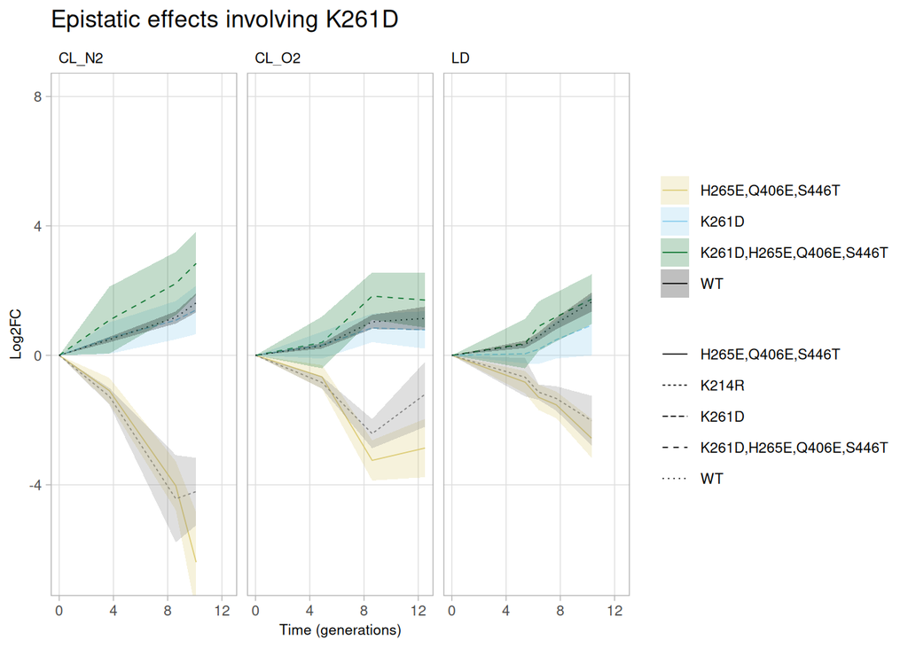

```r
different_colors_set <- c("K261D"="#88cceeff", "K261D,H265E,Q406E,S446T"="#117733ff", "H265E,Q406E,S446T"="#ddcc77ff", "WT"="black", neg_control_K214="darkgray")
p <- lineplot_CVinterval_severalColours_meanlog2(plot_subset) + labs(title="Epistatic effects involving K261D") + scale_fill_manual(values=different_colors_set) + scale_color_manual(values=different_colors_set)
p
```

```r
plot_subset <- subset(fitness_data, fitness_data$sgRNA_target %in% c("V337A", "H141V,M154A,K261F,H265A,V337A,Q406E,S446I", "H141V,M154A,K261F,H265A,Q406E,S446I", "WT", neg_control_K214))
unique(plot_subset[,c("sgRNA_target", "norm", "condition", "num_barcodes")])
```

| sgRNA_target | norm | condition | num_barcodes |
| --- | --- | --- | --- |
| H141V,M154A,K261F,H265A,Q406E,S446I | 0.79518855 | CL_N2 | 3 |
| H141V,M154A,K261F,H265A,Q406E,S446I | 0.56321150 | CL_O2 | 3 |
| H141V,M154A,K261F,H265A,Q406E,S446I | 0.46077962 | LD | 3 |
| H141V,M154A,K261F,H265A,V337A,Q406E,S446I | 1.06821950 | CL_N2 | 1 |
| H141V,M154A,K261F,H265A,V337A,Q406E,S446I | 2.28786430 | CL_O2 | 1 |
| H141V,M154A,K261F,H265A,V337A,Q406E,S446I | 1.52265646 | LD | 1 |
| K214R | 0.00000000 | CL_N2 | 5 |
| K214R | -0.04337233 | CL_O2 | 5 |
| K214R | -0.06588767 | LD | 5 |
| V337A | 0.32430028 | CL_N2 | 5 |

[output cut: 5 more lines]

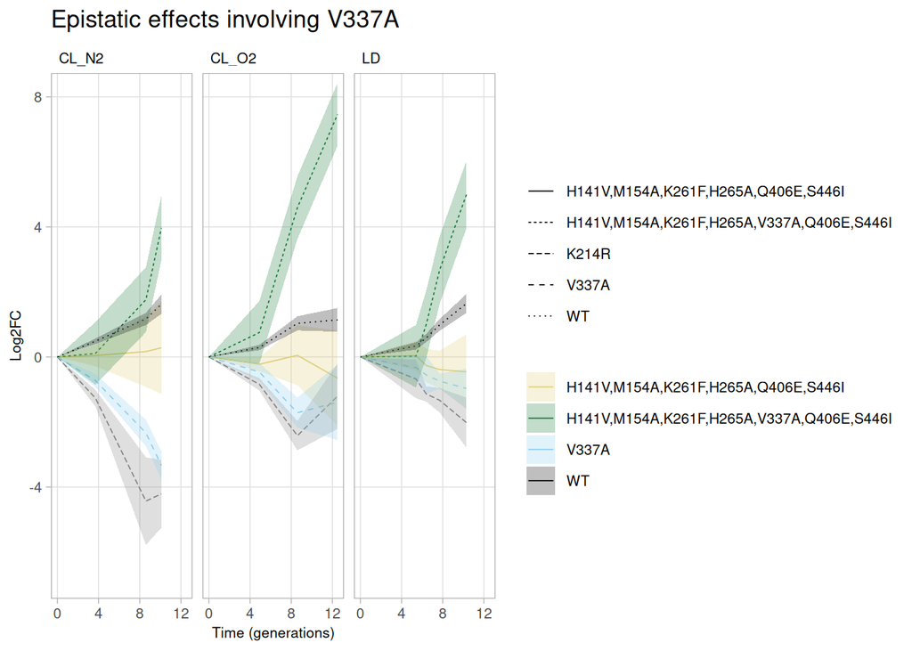

```r
different_colors_set <- c("V337A"="#88cceeff", "H141V,M154A,K261F,H265A,V337A,Q406E,S446I"="#117733ff", "H141V,M154A,K261F,H265A,Q406E,S446I"="#ddcc77ff", "WT"="black", neg_control_K214="darkgray")
p <- lineplot_CVinterval_severalColours_meanlog2(plot_subset) + labs(title="Epistatic effects involving V337A") + scale_fill_manual(values=different_colors_set) + scale_color_manual(values=different_colors_set)
p
```

```r
ggsave("../lfcSE_weighted_outputImages/pdf/epistatic-effects-V337A.pdf", plot=p, width=20, height=20)

plot_subset <- subset(fitness_data, fitness_data$sgRNA_target %in% c("Q406E", "H141V,M154A,K261F,H265A,V337A,Q406E,S446I", "H141V,M154A,K261F,H265A,V337A,S446I", "WT", neg_control_K214))
unique(plot_subset[,c("sgRNA_target", "norm", "condition", "num_barcodes")])
```

| sgRNA_target | norm | condition | num_barcodes |
| --- | --- | --- | --- |
| H141V,M154A,K261F,H265A,V337A,Q406E,S446I | 1.06821950 | CL_N2 | 1 |
| H141V,M154A,K261F,H265A,V337A,Q406E,S446I | 2.28786430 | CL_O2 | 1 |
| H141V,M154A,K261F,H265A,V337A,Q406E,S446I | 1.52265646 | LD | 1 |
| H141V,M154A,K261F,H265A,V337A,S446I | 0.30881966 | CL_N2 | 1 |
| H141V,M154A,K261F,H265A,V337A,S446I | -0.40293834 | CL_O2 | 1 |
| H141V,M154A,K261F,H265A,V337A,S446I | 0.10888724 | LD | 1 |
| K214R | 0.00000000 | CL_N2 | 5 |
| K214R | -0.04337233 | CL_O2 | 5 |
| K214R | -0.06588767 | LD | 5 |
| Q406E | 1.12076289 | CL_N2 | 5 |

[output cut: 5 more lines]

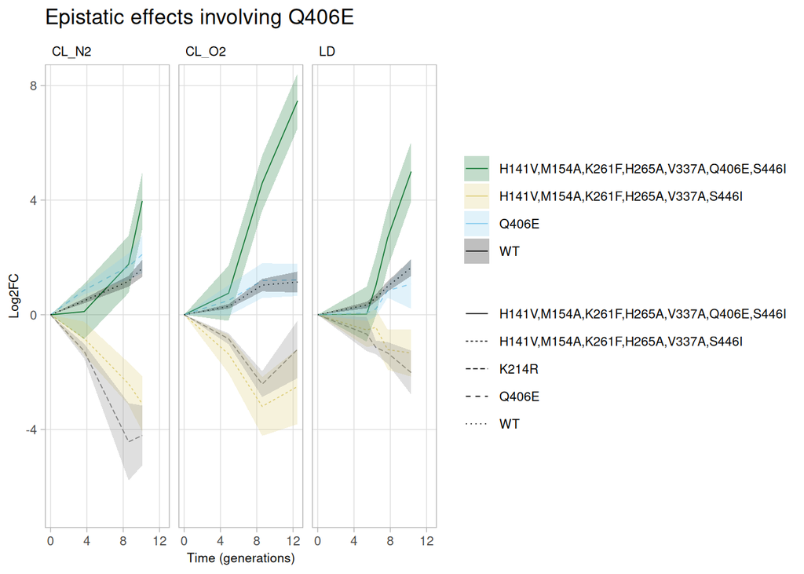

```r
different_colors_set <- c("Q406E"="#88cceeff", "H141V,M154A,K261F,H265A,V337A,Q406E,S446I"="#117733ff", "H141V,M154A,K261F,H265A,V337A,S446I"="#ddcc77ff", "WT"="black", neg_control_K214="darkgray")
p <- lineplot_CVinterval_severalColours_meanlog2(plot_subset) + labs(title="Epistatic effects involving Q406E") + scale_fill_manual(values=different_colors_set) + scale_color_manual(values=different_colors_set)
p
```

```r
ggsave("../lfcSE_weighted_outputImages/pdf/epistatic-effects-Q406E.pdf", plot=p, width=20, height=20)

plot_subset <- subset(fitness_data, fitness_data$sgRNA_target %in% c("Q406E", "H141V,M154A,Q406E", "H141V,M154A", "WT", neg_control_K214))
unique(plot_subset[,c("sgRNA_target", "norm", "condition", "num_barcodes")])
```

| sgRNA_target | norm | condition | num_barcodes |
| --- | --- | --- | --- |
| H141V,M154A,Q406E | 1.07728386 | CL_N2 | 1 |
| H141V,M154A,Q406E | 1.21885974 | CL_O2 | 1 |
| H141V,M154A,Q406E | 1.08295698 | LD | 1 |
| H141V,M154A | 0.01224885 | CL_N2 | 1 |
| H141V,M154A | -0.00215318 | CL_O2 | 1 |
| H141V,M154A | 0.14992114 | LD | 1 |
| K214R | 0.00000000 | CL_N2 | 5 |
| K214R | -0.04337233 | CL_O2 | 5 |
| K214R | -0.06588767 | LD | 5 |
| Q406E | 1.12076289 | CL_N2 | 5 |

[output cut: 5 more lines]

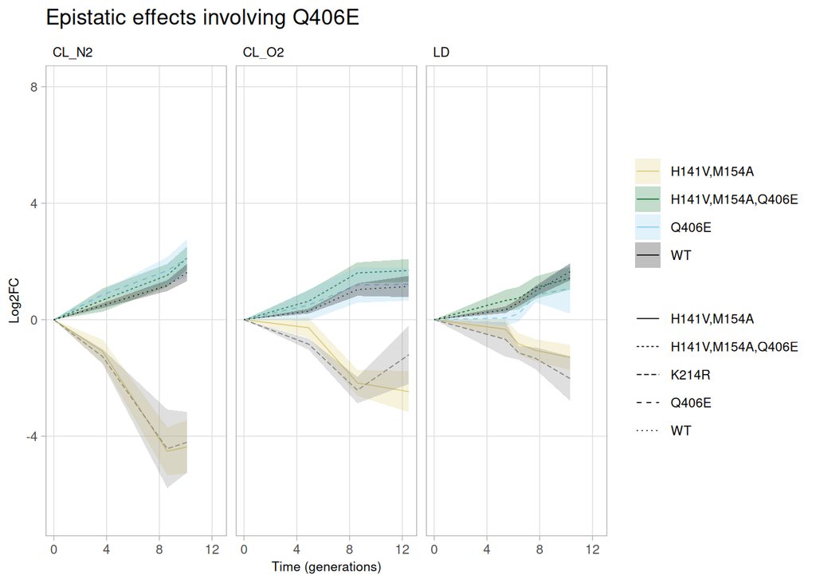

```r
different_colors_set <- c("Q406E"="#88cceeff", "H141V,M154A,Q406E"="#117733ff", "H141V,M154A"="#ddcc77ff", "WT"="black", neg_control_K214="darkgray")
p <- lineplot_CVinterval_severalColours_meanlog2(plot_subset) + labs(title="Epistatic effects involving Q406E") + scale_fill_manual(values=different_colors_set) + scale_color_manual(values=different_colors_set)
p
```

```r
plot_subset <- subset(fitness_data, fitness_data$sgRNA_target %in% c("K261A", "K261A,H265K,Q406E,S446A", "H265K,Q406E,S446A", "WT", neg_control_K214))
unique(plot_subset[,c("sgRNA_target", "norm", "condition", "num_barcodes")])
```

| sgRNA_target | norm | condition | num_barcodes |
| --- | --- | --- | --- |
| H265K,Q406E,S446A | 0.62418897 | CL_N2 | 1 |
| H265K,Q406E,S446A | 0.35952491 | CL_O2 | 1 |
| H265K,Q406E,S446A | 0.51648122 | LD | 1 |
| K214R | 0.00000000 | CL_N2 | 5 |
| K214R | -0.04337233 | CL_O2 | 5 |
| K214R | -0.06588767 | LD | 5 |
| K261A,H265K,Q406E,S446A | 1.17929771 | CL_N2 | 1 |
| K261A,H265K,Q406E,S446A | 1.16349443 | CL_O2 | 1 |
| K261A,H265K,Q406E,S446A | 1.19521474 | LD | 1 |
| K261A | 0.95187746 | CL_N2 | 8 |

[output cut: 5 more lines]

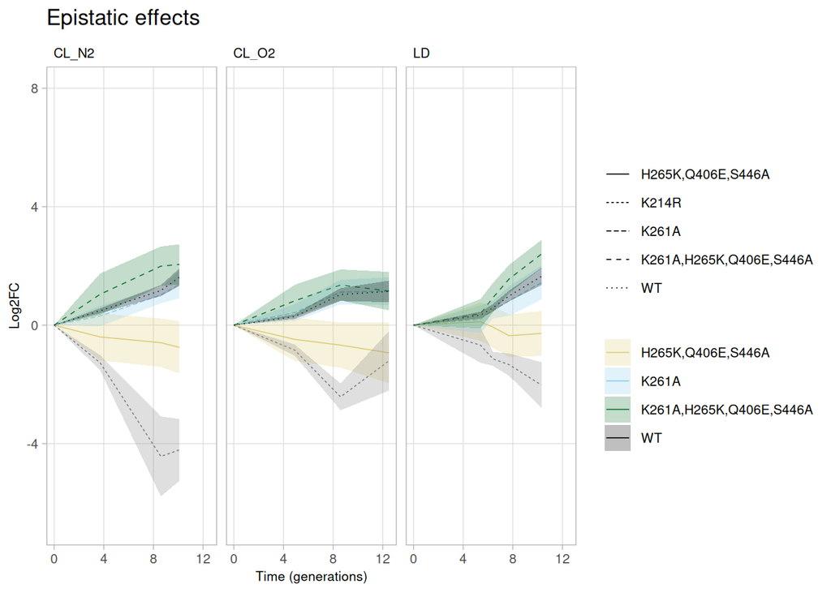

```r
different_colors_set <- c("K261A"="#88cceeff", "K261A,H265K,Q406E,S446A"="#117733ff", "H265K,Q406E,S446A"="#ddcc77ff", "WT"="black", neg_control_K214="darkgray")
p <- lineplot_CVinterval_severalColours_meanlog2(plot_subset) + labs(title="Epistatic effects") + scale_fill_manual(values=different_colors_set) + scale_color_manual(values=different_colors_set)
p
```

```r
plot_subset <- subset(fitness_data, fitness_data$sgRNA_target %in% c("H265A", "M154A,K261A,H265A,Q406D", "M154A,K261A,Q406D", "WT", neg_control_K214))
unique(plot_subset[,c("sgRNA_target", "norm", "condition", "num_barcodes")])
```

| sgRNA_target | norm | condition | num_barcodes |
| --- | --- | --- | --- |
| H265A | 0.86834174 | CL_N2 | 8 |
| H265A | 0.78045925 | CL_O2 | 8 |
| H265A | 0.90716106 | LD | 8 |
| K214R | 0.00000000 | CL_N2 | 5 |
| K214R | -0.04337233 | CL_O2 | 5 |
| K214R | -0.06588767 | LD | 5 |
| M154A,K261A,H265A,Q406D | 1.05368298 | CL_N2 | 1 |
| M154A,K261A,H265A,Q406D | 1.17653671 | CL_O2 | 1 |
| M154A,K261A,H265A,Q406D | 1.10058212 | LD | 1 |
| M154A,K261A,Q406D | 0.59813217 | CL_N2 | 1 |

[output cut: 5 more lines]

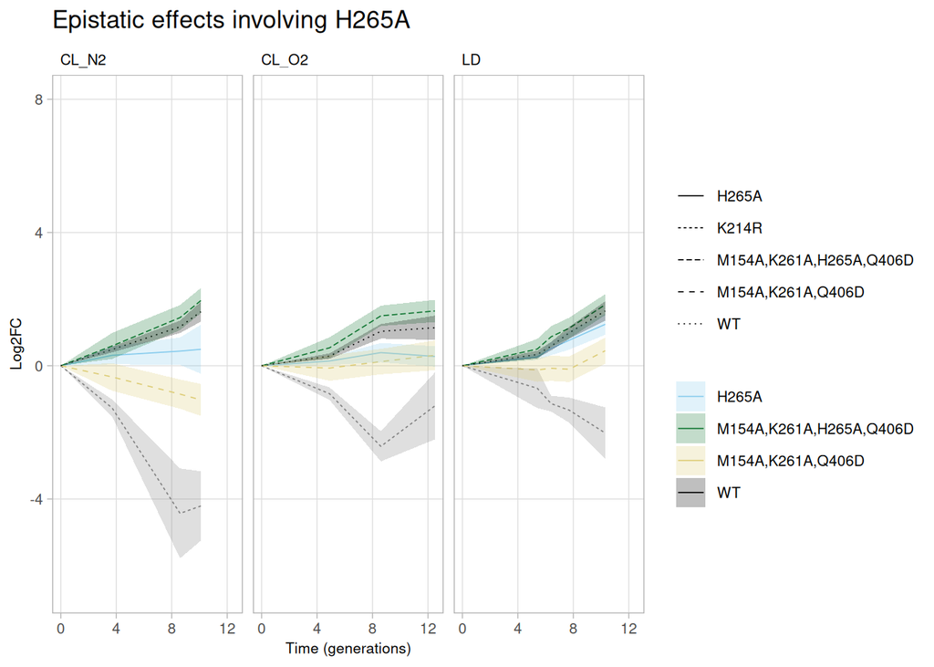

```r
different_colors_set <- c("H265A"="#88cceeff", "M154A,K261A,H265A,Q406D"="#117733ff", "M154A,K261A,Q406D"="#ddcc77ff", "WT"="black", neg_control_K214="darkgray")
p <- lineplot_CVinterval_severalColours_meanlog2(plot_subset) + labs(title="Epistatic effects involving H265A") + scale_fill_manual(values=different_colors_set) + scale_color_manual(values=different_colors_set)
p
```

```r
plot_subset <- subset(fitness_data, fitness_data$sgRNA_target %in% c("S446T", "M154A,K261A,Q406D,S446T", "M154A,K261A,Q406D", "WT", neg_control_K214))
unique(plot_subset[,c("sgRNA_target", "norm", "condition", "num_barcodes")])
```

| sgRNA_target | norm | condition | num_barcodes |
| --- | --- | --- | --- |
| K214R | 0.00000000 | CL_N2 | 5 |
| K214R | -0.04337233 | CL_O2 | 5 |
| K214R | -0.06588767 | LD | 5 |
| M154A,K261A,Q406D,S446T | 1.18858429 | CL_N2 | 1 |
| M154A,K261A,Q406D,S446T | 1.42873775 | CL_O2 | 1 |
| M154A,K261A,Q406D,S446T | 1.19801530 | LD | 1 |
| M154A,K261A,Q406D | 0.59813217 | CL_N2 | 1 |
| M154A,K261A,Q406D | 0.69382011 | CL_O2 | 1 |
| M154A,K261A,Q406D | 0.56439663 | LD | 1 |
| S446T | 1.03416258 | CL_N2 | 5 |

[output cut: 5 more lines]

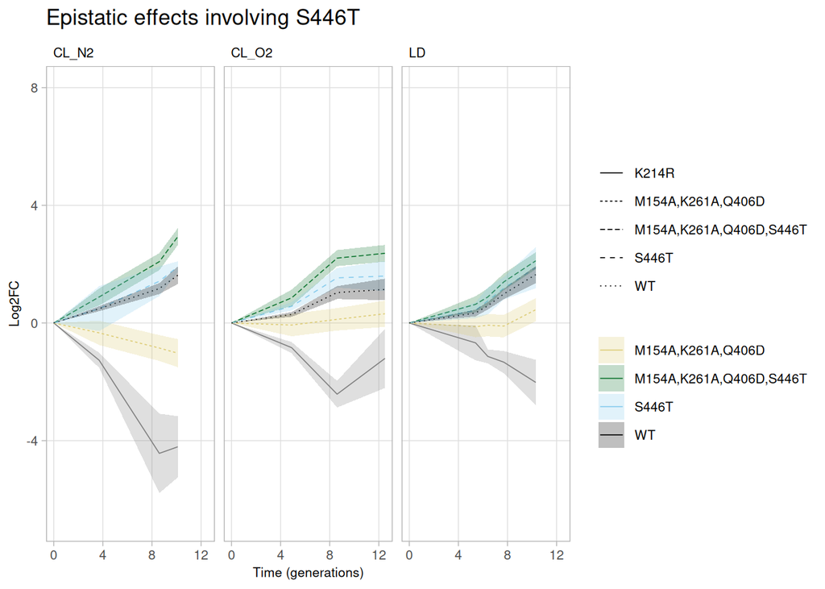

```r
different_colors_set <- c("S446T"="#88cceeff", "M154A,K261A,Q406D,S446T"="#117733ff", "M154A,K261A,Q406D"="#ddcc77ff", "WT"="black", neg_control_K214="darkgray")
p <- lineplot_CVinterval_severalColours_meanlog2(plot_subset) + labs(title="Epistatic effects involving S446T") + scale_fill_manual(values=different_colors_set) + scale_color_manual(values=different_colors_set)
p
```

```r
plot_subset <- subset(fitness_data, fitness_data$sgRNA_target %in% c("K261F", "K261F,H265K,Q406D,S446I", "H265K,Q406D,S446I", "WT", neg_control_K214))
unique(plot_subset[,c("sgRNA_target", "norm", "condition", "num_barcodes")])
```

| sgRNA_target | norm | condition | num_barcodes |
| --- | --- | --- | --- |
| H265K,Q406D,S446I | 0.83999146 | CL_N2 | 1 |
| H265K,Q406D,S446I | 0.81920247 | CL_O2 | 1 |
| H265K,Q406D,S446I | 0.80879980 | LD | 1 |
| K214R | 0.00000000 | CL_N2 | 5 |
| K214R | -0.04337233 | CL_O2 | 5 |
| K214R | -0.06588767 | LD | 5 |
| K261F,H265K,Q406D,S446I | 1.06414695 | CL_N2 | 1 |
| K261F,H265K,Q406D,S446I | 1.29373429 | CL_O2 | 1 |
| K261F,H265K,Q406D,S446I | 1.11068260 | LD | 1 |
| K261F | 0.83666713 | CL_N2 | 6 |

[output cut: 5 more lines]

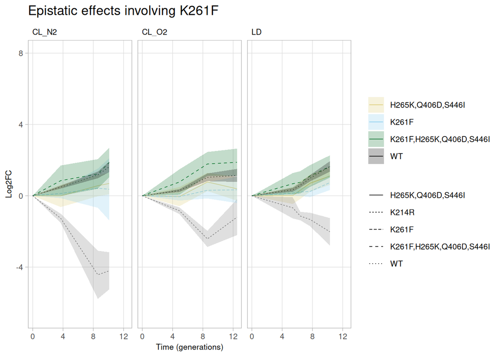

```r
different_colors_set <- c("K261F"="#88cceeff", "K261F,H265K,Q406D,S446I"="#117733ff", "H265K,Q406D,S446I"="#ddcc77ff", "WT"="black", neg_control_K214="darkgray")
p <- lineplot_CVinterval_severalColours_meanlog2(plot_subset) + labs(title="Epistatic effects involving K261F") + scale_fill_manual(values=different_colors_set) + scale_color_manual(values=different_colors_set)
p
```

```r
plot_subset <- subset(fitness_data, fitness_data$sgRNA_target %in% c("H265E", "K261D,H265E,Q406E,S446T", "K261D,Q406E,S446T", "WT", neg_control_K214))
unique(plot_subset[,c("sgRNA_target", "norm", "condition", "num_barcodes")])
```

| sgRNA_target | norm | condition | num_barcodes |
| --- | --- | --- | --- |
| H265E | 0.80032398 | CL_N2 | 7 |
| H265E | 0.69557805 | CL_O2 | 7 |
| H265E | 0.76251540 | LD | 7 |
| K214R | 0.00000000 | CL_N2 | 5 |
| K214R | -0.04337233 | CL_O2 | 5 |
| K214R | -0.06588767 | LD | 5 |
| K261D,H265E,Q406E,S446T | 1.22956081 | CL_N2 | 1 |
| K261D,H265E,Q406E,S446T | 1.21201136 | CL_O2 | 1 |
| K261D,H265E,Q406E,S446T | 1.06927729 | LD | 1 |
| K261D,Q406E,S446T | 0.93127101 | CL_N2 | 3 |

[output cut: 5 more lines]

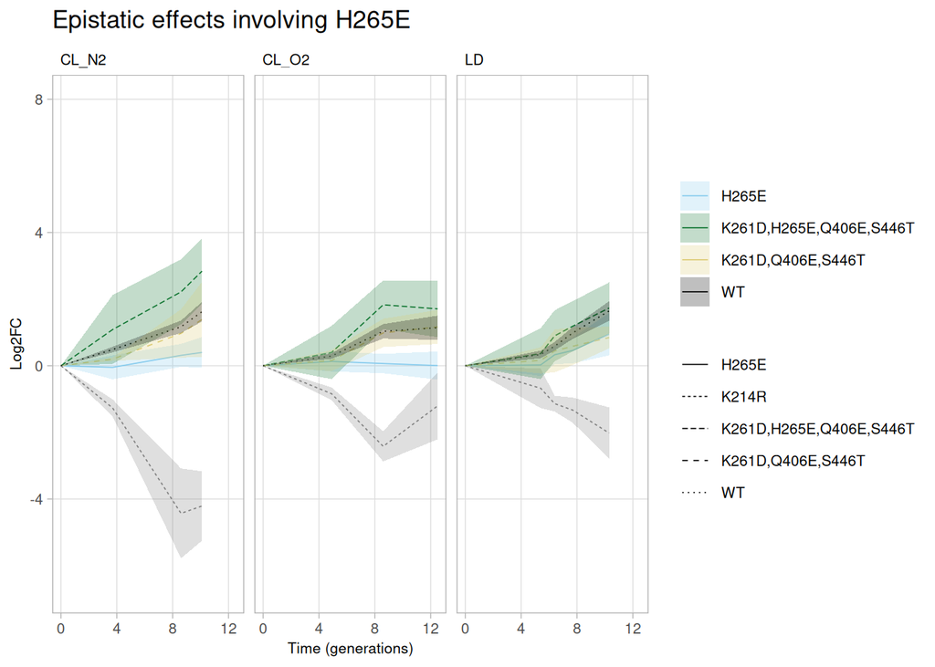

```r
different_colors_set <- c("H265E"="#88cceeff", "K261D,H265E,Q406E,S446T"="#117733ff", "K261D,Q406E,S446T"="#ddcc77ff", "WT"="black", neg_control_K214="darkgray")
p <- lineplot_CVinterval_severalColours_meanlog2(plot_subset) + labs(title="Epistatic effects involving H265E") + scale_fill_manual(values=different_colors_set) + scale_color_manual(values=different_colors_set)
p
```

```r
plot_subset <- subset(fitness_data, fitness_data$sgRNA_target %in% c("K261A", "K261A,H265K,Q406E,S446A", "H265K,Q406E,S446A", "WT", neg_control_K214))
unique(plot_subset[,c("sgRNA_target", "norm", "condition", "num_barcodes")])
```

| sgRNA_target | norm | condition | num_barcodes |
| --- | --- | --- | --- |
| H265K,Q406E,S446A | 0.62418897 | CL_N2 | 1 |
| H265K,Q406E,S446A | 0.35952491 | CL_O2 | 1 |
| H265K,Q406E,S446A | 0.51648122 | LD | 1 |
| K214R | 0.00000000 | CL_N2 | 5 |
| K214R | -0.04337233 | CL_O2 | 5 |
| K214R | -0.06588767 | LD | 5 |
| K261A,H265K,Q406E,S446A | 1.17929771 | CL_N2 | 1 |
| K261A,H265K,Q406E,S446A | 1.16349443 | CL_O2 | 1 |
| K261A,H265K,Q406E,S446A | 1.19521474 | LD | 1 |
| K261A | 0.95187746 | CL_N2 | 8 |

[output cut: 5 more lines]

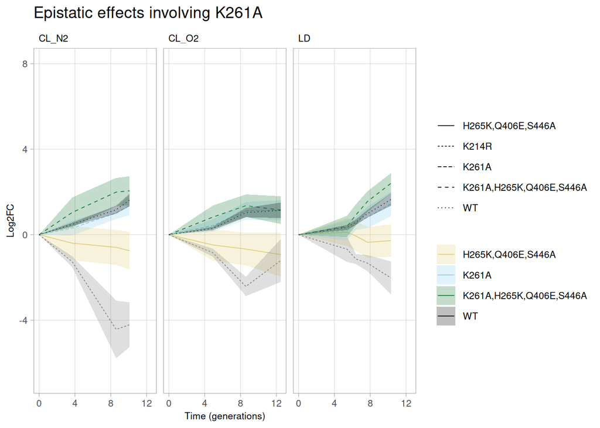

```r
different_colors_set <- c("K261A"="#88cceeff", "K261A,H265K,Q406E,S446A"="#117733ff", "H265K,Q406E,S446A"="#ddcc77ff", "WT"="black", neg_control_K214="darkgray")
p <- lineplot_CVinterval_severalColours_meanlog2(plot_subset) + labs(title="Epistatic effects involving K261A") + scale_fill_manual(values=different_colors_set) + scale_color_manual(values=different_colors_set)
p
```

# Variants for which mutant strains exist

“variant H141V,K261A,H265K,Q406E,S446I with the highest fitness value in the library, but shitty adjusted p value, is H141V,K261A,H265K,Q406E,S446I (norm=2.18, p.adj=0.107), alternative option for showing epistasis (besides D and E), needs control strains H141V, K261A, Q406E, S446I and H265K to show that H265K is detrimental when introduced on its own, beneficial in background of quardruple mutant”

```r
plot_subset <- subset(fitness_data, fitness_data$sgRNA_target %in% c("H141V,K261A,H265K,Q406E,S446I", "H141V,K261A,Q406E,S446I", "H265K", "WT", neg_control_K214))
unique(plot_subset[,c("sgRNA_target", "norm", "condition", "num_barcodes")])
```

| sgRNA_target | norm | condition | num_barcodes |
| --- | --- | --- | --- |
| H141V,K261A,H265K,Q406E,S446I | 1.69581835 | CL_N2 | 1 |
| H141V,K261A,H265K,Q406E,S446I | 1.38493626 | CL_O2 | 1 |
| H141V,K261A,H265K,Q406E,S446I | 1.20811562 | LD | 1 |
| H141V,K261A,Q406E,S446I | 1.26412168 | CL_N2 | 1 |
| H141V,K261A,Q406E,S446I | 1.73357036 | CL_O2 | 1 |
| H141V,K261A,Q406E,S446I | 1.28596955 | LD | 1 |
| H265K | 0.73692220 | CL_N2 | 7 |
| H265K | 0.54905941 | CL_O2 | 7 |
| H265K | 0.68471896 | LD | 7 |
| K214R | 0.00000000 | CL_N2 | 5 |

[output cut: 5 more lines]

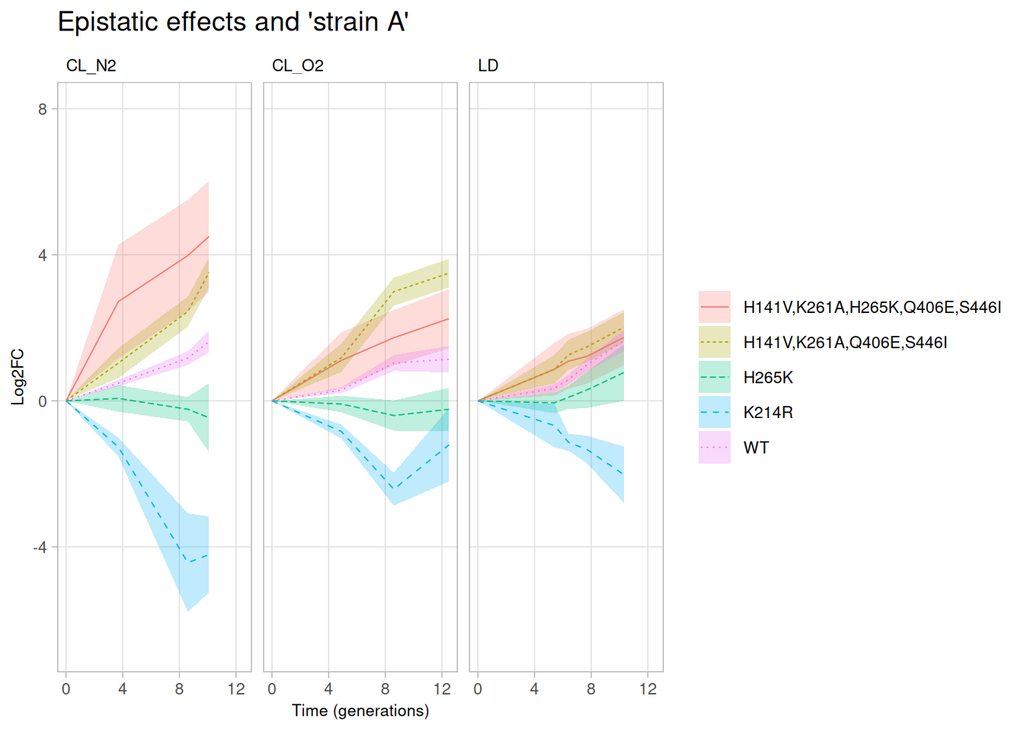

```r
p <- lineplot_CVinterval_severalColours_meanlog2(plot_subset) + labs(title="Epistatic effects and 'strain A'")
p
```

H141V, M154A, K261A, H265A, Q406E, S446T other alternative option for showing epistasis (besides E), there should also be a corresponding mutant with 5 exchanges (H141V, M154A, K261A, Q406E, S446T) and then the comparison that H265A is detrimental on its own, but beneficial in the background of the mutant with 5 exchagnes

```r
plot_subset <- subset(fitness_data, fitness_data$sgRNA_target %in% c("H141V,M154A,K261A,H265A,Q406E,S446T", "H141V,M154A,K261A,Q406E,S446T", "H265A", "WT", neg_control_K214))
unique(plot_subset[,c("sgRNA_target", "norm", "condition", "num_barcodes")])
```

| sgRNA_target | norm | condition | num_barcodes |
| --- | --- | --- | --- |
| H141V,M154A,K261A,H265A,Q406E,S446T | 1.24308759 | CL_N2 | 4 |
| H141V,M154A,K261A,H265A,Q406E,S446T | 1.55414178 | CL_O2 | 4 |
| H141V,M154A,K261A,H265A,Q406E,S446T | 1.24836069 | LD | 4 |
| H141V,M154A,K261A,Q406E,S446T | 1.26792885 | CL_N2 | 2 |
| H141V,M154A,K261A,Q406E,S446T | 1.47340656 | CL_O2 | 2 |
| H141V,M154A,K261A,Q406E,S446T | 0.73200070 | LD | 2 |
| H265A | 0.86834174 | CL_N2 | 8 |
| H265A | 0.78045925 | CL_O2 | 8 |
| H265A | 0.90716106 | LD | 8 |
| K214R | 0.00000000 | CL_N2 | 5 |

[output cut: 5 more lines]

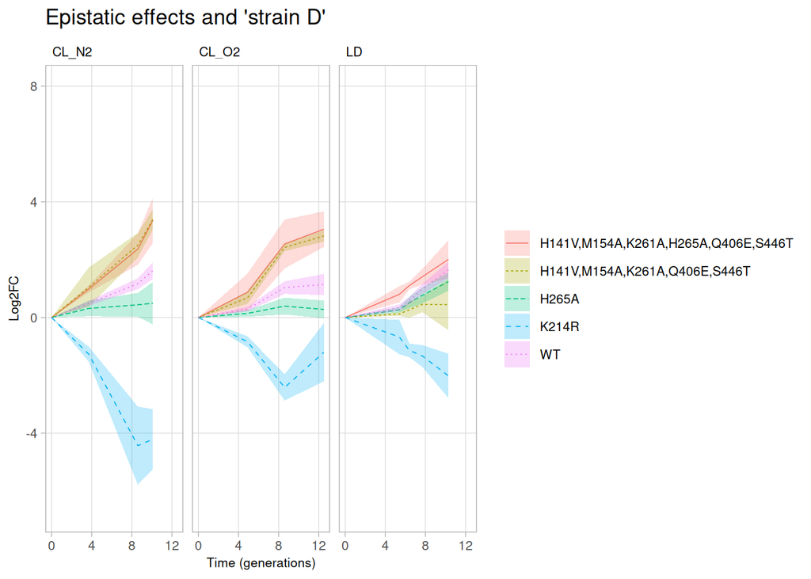

```r
p <- lineplot_CVinterval_severalColours_meanlog2(plot_subset) + labs(title="Epistatic effects and 'strain D'")
p
```

H141V, K261E, H265A, S446A “fittest combinatorial mutant variant with a significant difference has four amino acid exchanges: H141V,K261E,H265A,S446A (norm=1.56, p.adj=0.0259) , main line Figure showing epistasis, there should also be a corresponding triple mutant (H141V, K261E, S446A) showing that H265A on its own is detrimental, in background of H141V, K261E, S446A beneficial”

```r
plot_subset <- subset(fitness_data, fitness_data$sgRNA_target %in% c("H141V,K261E,H265A,S446A", "H141V,K261E,S446A", "H265A", "WT", neg_control_K214))
unique(plot_subset[,c("sgRNA_target", "norm", "condition", "num_barcodes")])
```

| sgRNA_target | norm | condition | num_barcodes |
| --- | --- | --- | --- |
| H141V,K261E,H265A,S446A | 1.34047538 | CL_N2 | 2 |
| H141V,K261E,H265A,S446A | 1.24492463 | CL_O2 | 2 |
| H141V,K261E,H265A,S446A | 0.87755249 | LD | 2 |
| H141V,K261E,S446A | 0.82215465 | CL_N2 | 3 |
| H141V,K261E,S446A | 0.95290908 | CL_O2 | 3 |
| H141V,K261E,S446A | 0.73871139 | LD | 3 |
| H265A | 0.86834174 | CL_N2 | 8 |
| H265A | 0.78045925 | CL_O2 | 8 |
| H265A | 0.90716106 | LD | 8 |
| K214R | 0.00000000 | CL_N2 | 5 |

[output cut: 5 more lines]

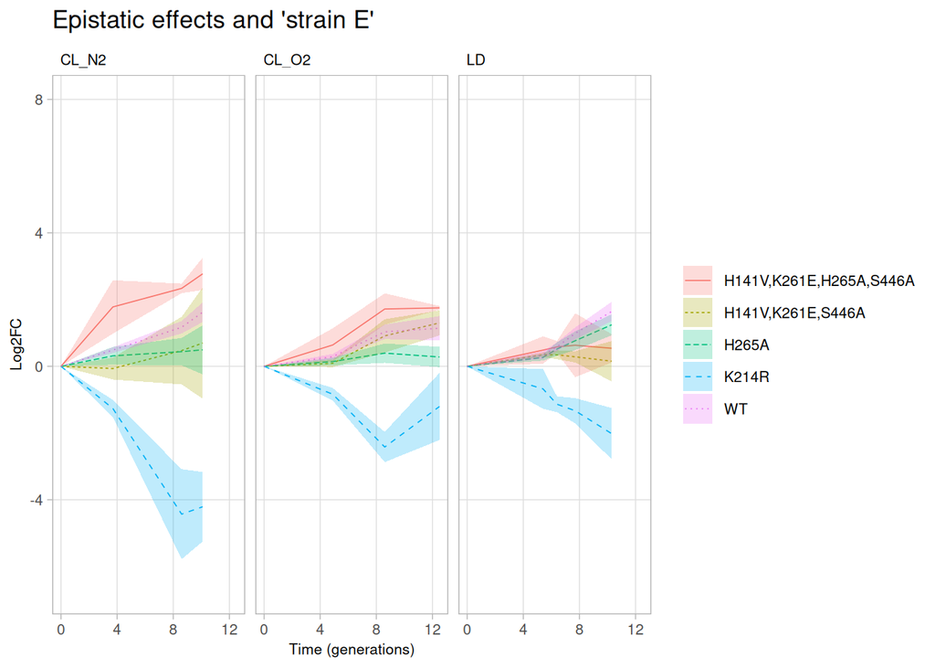

```r
p <- lineplot_CVinterval_severalColours_meanlog2(plot_subset) + labs(title="Epistatic effects and 'strain E'")
p
```

Variant underlying the suggested higher-order variants: H141V, K261A, H265A, Q406E, S446T

```r
different_colors_set <- c("W128I"="#88cceeff", "H141V,K261A,H265A,Q406E,S446T"="#117733ff", "K360I"="#ddcc77ff", "WT"="black", neg_control_K214="darkgray")
plot_subset <- subset(fitness_data, fitness_data$sgRNA_target %in% c("H141V,K261A,H265A,Q406E,S446T", "W128I", "K360I", "WT", neg_control_K214))
unique(plot_subset[,c("sgRNA_target", "norm", "condition", "num_barcodes")])
```

| sgRNA_target | norm | condition | num_barcodes |
| --- | --- | --- | --- |
| H141V,K261A,H265A,Q406E,S446T | 1.26538898 | CL_N2 | 2 |
| H141V,K261A,H265A,Q406E,S446T | 1.73279608 | CL_O2 | 2 |
| H141V,K261A,H265A,Q406E,S446T | 1.19364894 | LD | 2 |
| K214R | 0.00000000 | CL_N2 | 5 |
| K214R | -0.04337233 | CL_O2 | 5 |
| K214R | -0.06588767 | LD | 5 |
| K360I | 1.39979386 | CL_N2 | 14 |
| K360I | 1.98169832 | CL_O2 | 14 |
| K360I | 1.37744505 | LD | 14 |
| W128I | 1.42388817 | CL_N2 | 6 |

[output cut: 5 more lines]

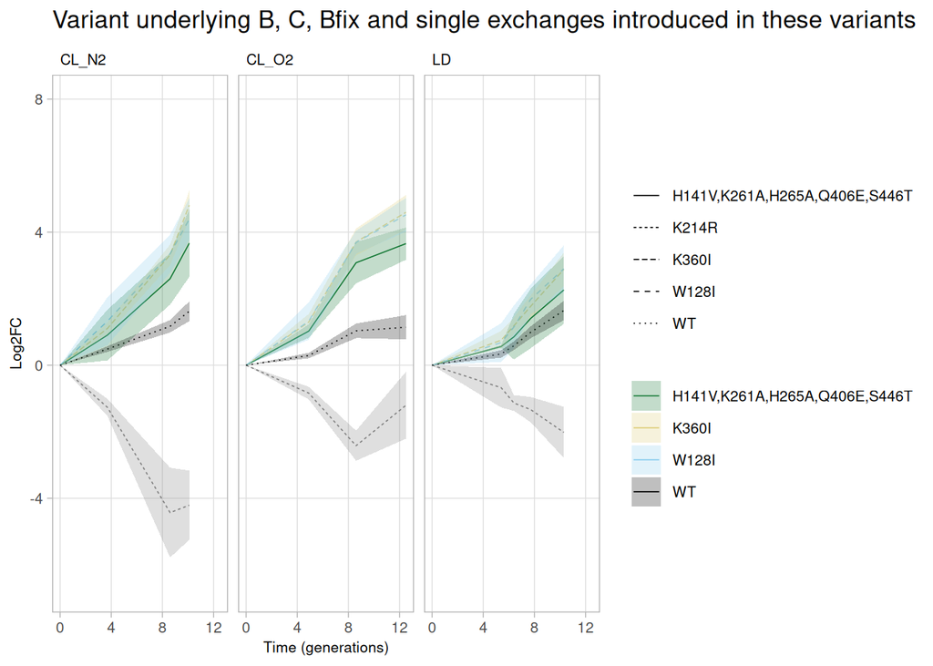

```r
p <- lineplot_CVinterval_severalColours_meanlog2(plot_subset) + labs(title="Variant underlying B, C, Bfix and single exchanges introduced in these variants") + scale_fill_manual(values=different_colors_set) + scale_color_manual(values=different_colors_set)
p
```

```r
ggsave("../lfcSE_weighted_outputImages/pdf/variant_underlying_B-C-Bfix.pdf", plot=p, width=20, height=20)
```

W128I single exchange with high fitness value, H358S single exchange with high fitness value, K360I single exchange with high fitness value

```r
plot_subset <- subset(fitness_data, fitness_data$sgRNA_target %in% c("W128I", "H358S", "K360I", "WT", neg_control_K214))
unique(plot_subset[,c("sgRNA_target", "norm", "condition", "num_barcodes")])
```

| sgRNA_target | norm | condition | num_barcodes |
| --- | --- | --- | --- |
| H358S | 1.44631001 | CL_N2 | 11 |
| H358S | 2.10739658 | CL_O2 | 11 |
| H358S | 1.04179333 | LD | 11 |
| K214R | 0.00000000 | CL_N2 | 5 |
| K214R | -0.04337233 | CL_O2 | 5 |
| K214R | -0.06588767 | LD | 5 |
| K360I | 1.39979386 | CL_N2 | 14 |
| K360I | 1.98169832 | CL_O2 | 14 |
| K360I | 1.37744505 | LD | 14 |
| W128I | 1.42388817 | CL_N2 | 6 |

[output cut: 5 more lines]

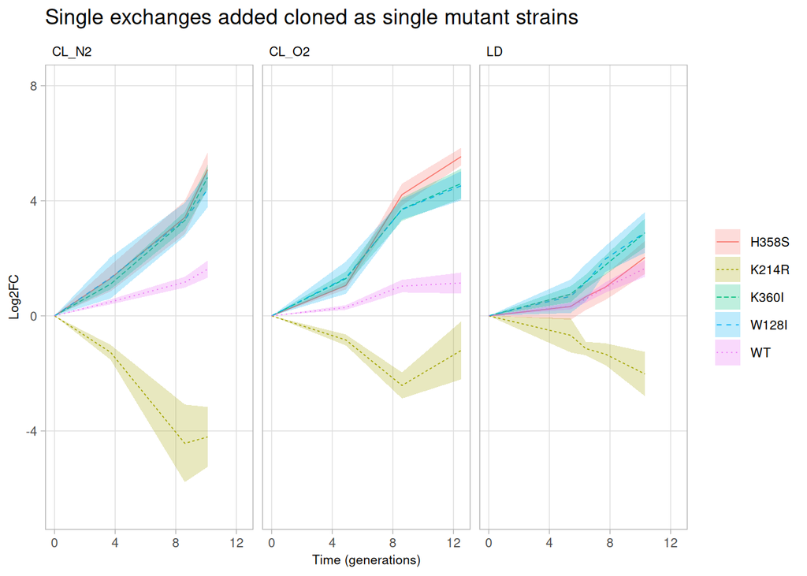

```r
p <- lineplot_CVinterval_severalColours_meanlog2(plot_subset) + labs(title="Single exchanges added cloned as single mutant strains")
p
```

Higher order variant with V98D, F104C, W128K, Q142D, K233I, V270L, M345I, H358S

```r
plot_subset <- subset(fitness_data, fitness_data$sgRNA_target %in% c("V98D", "F104C", "W128K", "Q142D", "K233I", "V270L", "M345I", "H358S", "WT", neg_control_K214))
unique(plot_subset[,c("sgRNA_target", "norm", "condition", "num_barcodes")])
```

| sgRNA_target | norm | condition | num_barcodes |
| --- | --- | --- | --- |
| F104C | 1.34183807 | CL_N2 | 2 |
| F104C | 1.47594239 | CL_O2 | 2 |
| F104C | 0.99694293 | LD | 2 |
| H358S | 1.44631001 | CL_N2 | 11 |
| H358S | 2.10739658 | CL_O2 | 11 |
| H358S | 1.04179333 | LD | 11 |
| K214R | 0.00000000 | CL_N2 | 5 |
| K214R | -0.04337233 | CL_O2 | 5 |
| K214R | -0.06588767 | LD | 5 |
| K233I | 1.35724360 | CL_N2 | 4 |

[output cut: 20 more lines]

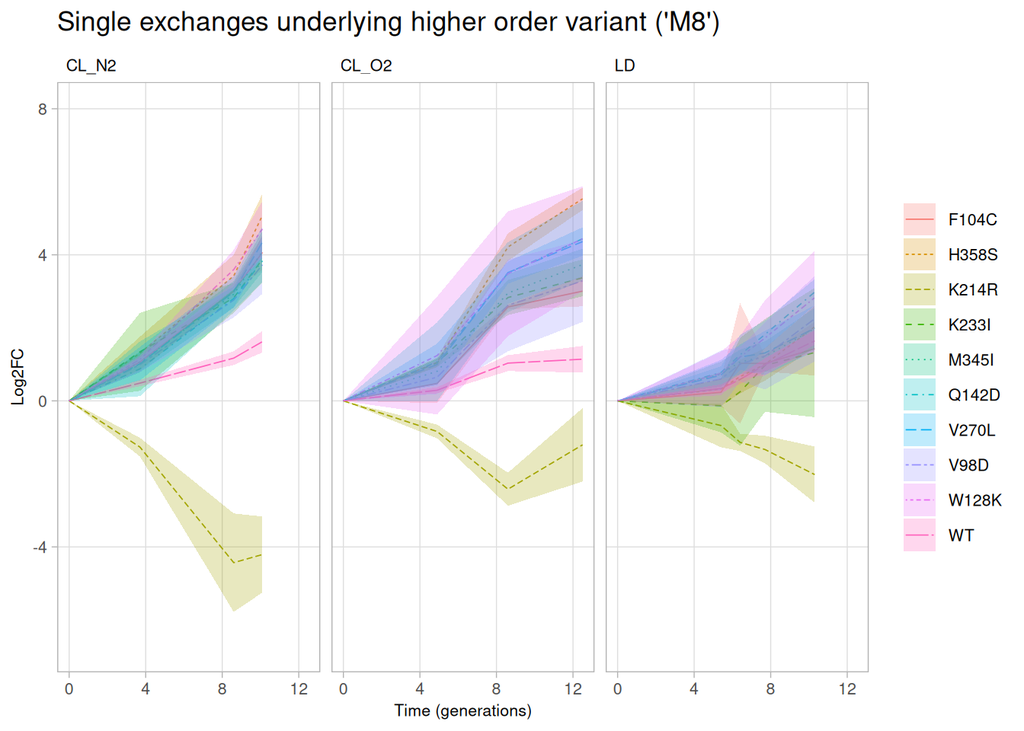

```r
p <- lineplot_CVinterval_severalColours_meanlog2(plot_subset) + labs(title="Single exchanges underlying higher order variant ('M8')")
p
```

# Other analyses for combinatorial library

```r
single_muts_combinatorial <- pivot_wider(unique(subset(fitness_data, fitness_data$category=="combiANDsatur")[,columns]), names_from=condition, values_from=c(norm, p_fit_adj_WT))
single_muts_combinatorial$norm_multiply <- single_muts_combinatorial$norm_CL_N2 * single_muts_combinatorial$norm_CL_O2 * single_muts_combinatorial$norm_LD
write.csv(single_muts_combinatorial, file="../lfcSE_weighted_outputImages/single_site_exchanges_combinatorialLibrary.csv")
single_muts_combinatorial[order(single_muts_combinatorial$norm_multiply, decreasing=TRUE),c(1,4,5,6,10,2,3,7,8,9)]
```

| sgRNA_target | norm_CL_N2 | norm_CL_O2 | norm_LD | norm_multiply | num_barcodes | number_muts | p_fit_adj_WT_CL_N2 | p_fit_adj_WT_CL_O2 | p_fit_adj_WT_LD |
| --- | --- | --- | --- | --- | --- | --- | --- | --- | --- |
| S446T | 1.0341626 | 1.1839690 | 1.0854515 | 1.32904461 | 5 | 1 | 4.057668e-01 | 1.583553e-02 | 0.4569687763 |
| H141V | 1.0168605 | 1.1887371 | 0.9639216 | 1.16516896 | 3 | 1 | 8.166326e-01 | 6.729319e-02 | 0.9386883629 |
| Q406E | 1.1207629 | 1.0764755 | 0.8266148 | 0.99728912 | 5 | 1 | 1.348802e-02 | 5.416705e-01 | 0.1990762900 |
| Q406D | 1.0135987 | 0.9462450 | 0.9613085 | 0.92200321 | 1 | 1 | 8.636906e-01 | 8.604765e-01 | 0.8558638862 |
| K261A | 0.9518775 | 1.0421205 | 0.9172866 | 0.90992175 | 8 | 1 | 9.433679e-01 | 4.854658e-01 | 0.7385660820 |
| S446A | 1.0208608 | 0.9367199 | 0.9162932 | 0.87621517 | 6 | 1 | 9.328078e-01 | 6.116071e-01 | 0.5291215586 |
| H141L | 0.9402071 | 1.1334984 | 0.7828454 | 0.83429653 | 5 | 1 | 6.969113e-01 | 3.099144e-01 | 0.0848931422 |
| K261D | 0.9920204 | 0.9398430 | 0.7575592 | 0.70630532 | 8 | 1 | 4.050951e-01 | 6.915083e-01 | 0.1892961422 |
| M154E | 0.8753147 | 1.0619508 | 0.7508696 | 0.69796416 | 3 | 1 | 1.366137e-02 | 9.817891e-01 | 0.1763415817 |
| S446I | 0.9386771 | 0.8690460 | 0.8405570 | 0.68568740 | 9 | 1 | 4.539505e-02 | 8.368766e-03 | 0.2439834167 |

[output cut: 11 more lines]

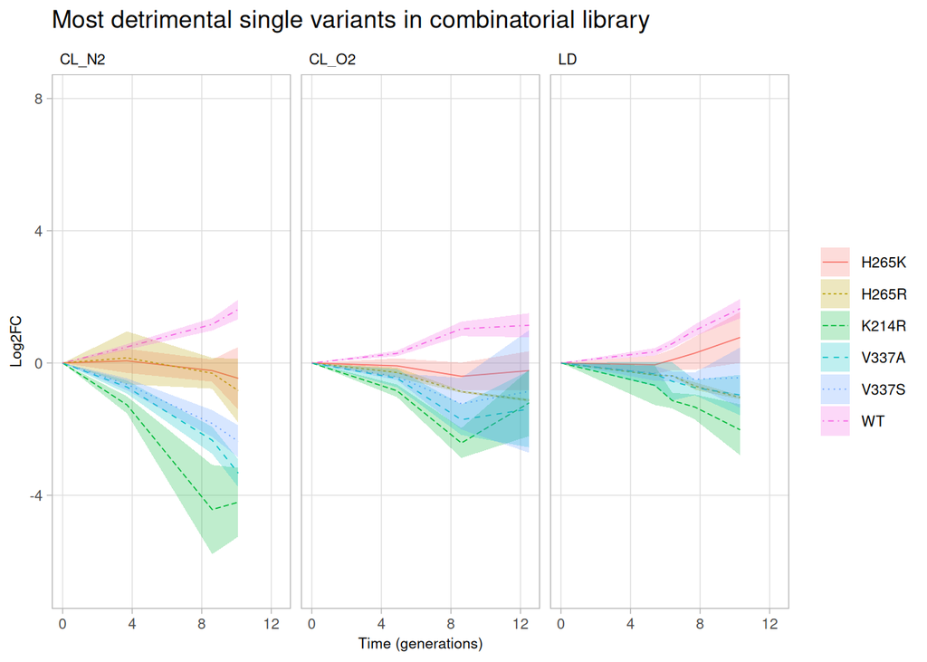

```r
combi_single_subset <- subset(fitness_data, fitness_data$sgRNA_target %in% c("WT", "H265K", "H265R", "V337A", "V337S", neg_control_K214))
p <- lineplot_CVinterval_severalColours_meanlog2(combi_single_subset) + labs(title="Most detrimental single variants in combinatorial library")
p
```

```r
for(n_mut in 2:7){
  print(n_mut)
  muts_combinatorial <- pivot_wider(unique(subset(fitness_data, fitness_data$number_muts==n_mut)[,columns]), names_from=condition, values_from=c(norm, p_fit_adj_WT))
  muts_combinatorial$norm_multiply <- muts_combinatorial$norm_CL_N2 * muts_combinatorial$norm_CL_O2 * muts_combinatorial$norm_LD
  print("Sorted according to product of different normed fitness values")
  print(head(muts_combinatorial[order(muts_combinatorial$norm_multiply, decreasing=TRUE),c(1,4,5,6,10,2,3,7,8,9)]))
  muts_combinatorial <- subset(muts_combinatorial, muts_combinatorial$norm_CL_N2 > 1.0 & muts_combinatorial$norm_CL_O2 > 1.0 & muts_combinatorial$norm_LD > 1.0)
  muts_combinatorial <- subset(muts_combinatorial, (muts_combinatorial$p_fit_adj_WT_CL_N2 < 0.05 | muts_combinatorial$p_fit_adj_WT_CL_O2 < 0.05 | muts_combinatorial$p_fit_adj_WT_LD < 0.05) & muts_combinatorial$norm_CL_N2 > 1.0 & muts_combinatorial$norm_CL_O2 > 1.0 & muts_combinatorial$norm_LD > 1.0)
  print("Only selecting for variants with a normed fitness value above 1 in all conditions and a significant difference to the base variant in at least one of the conditions")
  print(head(muts_combinatorial[order(muts_combinatorial$norm_multiply, decreasing=TRUE),c(1,4,5,6,10,2,3,7,8,9)]))
}
```

```
## [1] 2
## [1] "Sorted according to product of different normed fitness values"
## # A tibble: 6 × 10
##   sgRNA_target norm_CL_N2 norm_CL_O2 norm_LD norm_multiply num_barcodes
##   <chr>             <dbl>      <dbl>   <dbl>         <dbl>        <dbl>
## 1 H141V,S446I        1.19       1.59   1.20           2.27            1
## 2 K261A,S446T        1.29       1.56   1.02           2.05            1
## 3 Q406E,S446I        1.13       1.23   1.30           1.81            1
## 4 K261D,S446T        1.13       1.29   1.11           1.63            1
## 5 H141L,Q406D        1.21       1.45   0.885          1.56            2
## 6 Q406E,S446T        1.16       1.28   1.04           1.54            2
## # ℹ 4 more variables: number_muts <dbl>, p_fit_adj_WT_CL_N2 <dbl>,
## #   p_fit_adj_WT_CL_O2 <dbl>, p_fit_adj_WT_LD <dbl>
## [1] "Only selecting for variants with a normed fitness value above 1 in all conditions and a significant difference to the base variant in at least one of the conditions"
## # A tibble: 0 × 10
## # ℹ 10 variables: sgRNA_target <chr>, norm_CL_N2 <dbl>, norm_CL_O2 <dbl>,
## #   norm_LD <dbl>, norm_multiply <dbl>, num_barcodes <dbl>, number_muts <dbl>,
## #   p_fit_adj_WT_CL_N2 <dbl>, p_fit_adj_WT_CL_O2 <dbl>, p_fit_adj_WT_LD <dbl>
## [1] 3
## [1] "Sorted according to product of different normed fitness values"
## # A tibble: 6 × 10
##   sgRNA_target      norm_CL_N2 norm_CL_O2 norm_LD norm_multiply num_barcodes
##   <chr>                  <dbl>      <dbl>   <dbl>         <dbl>        <dbl>
## 1 H141V,Q406D,S446A       1.11       2.05    1.40          3.20            1
## 2 H141V,K261A,S446T       1.36       1.74    1.18          2.80            2
## 3 H141V,Q406E,S446T       1.25       1.65    1.25          2.56            2
## 4 K261F,Q406D,S446T       1.33       1.75    1.10          2.56            1
## 5 H141V,K261A,S446I       1.31       1.54    1.21          2.45            1
## 6 K261A,Q406E,S446T       1.27       1.48    1.25          2.35            2
## # ℹ 4 more variables: number_muts <dbl>, p_fit_adj_WT_CL_N2 <dbl>,
## #   p_fit_adj_WT_CL_O2 <dbl>, p_fit_adj_WT_LD <dbl>
## [1] "Only selecting for variants with a normed fitness value above 1 in all conditions and a significant difference to the base variant in at least one of the conditions"
## # A tibble: 6 × 10
##   sgRNA_target      norm_CL_N2 norm_CL_O2 norm_LD norm_multiply num_barcodes
##   <chr>                  <dbl>      <dbl>   <dbl>         <dbl>        <dbl>
## 1 H141V,K261A,S446T       1.36       1.74    1.18          2.80            2
## 2 H141V,Q406E,S446T       1.25       1.65    1.25          2.56            2
## 3 K261A,Q406E,S446T       1.27       1.48    1.25          2.35            2
## 4 K261A,H265A,S446A       1.22       1.26    1.21          1.86            2
## 5 K261A,Q406D,S446I       1.18       1.47    1.07          1.85            3
```

[output cut: 81 more lines]

```
##   sgRNA_target          norm_CL_N2 norm_CL_O2 norm_LD norm_multiply num_barcodes
##   <chr>                      <dbl>      <dbl>   <dbl>         <dbl>        <dbl>
## 1 H141V,M154A,K261F,H2…      1.07       2.29    1.52          3.72             1
## 2 H141L,M154K,K261F,H2…      0.797      1.68    1.13          1.51             1
## 3 H141V,M154E,K261D,H2…      0.530      1.40    0.987         0.734            1
## 4 H141L,M154D,K261D,H2…      0.541      1.33    0.954         0.684            1
## 5 H141V,M154D,K261A,H2…      0.660      1.09    0.760         0.544            1
## 6 H141V,M154K,K261A,H2…      0.830      0.710   0.845         0.498            1
## # ℹ 4 more variables: number_muts <dbl>, p_fit_adj_WT_CL_N2 <dbl>,
## #   p_fit_adj_WT_CL_O2 <dbl>, p_fit_adj_WT_LD <dbl>
## [1] "Only selecting for variants with a normed fitness value above 1 in all conditions and a significant difference to the base variant in at least one of the conditions"
## # A tibble: 0 × 10
## # ℹ 10 variables: sgRNA_target <chr>, norm_CL_N2 <dbl>, norm_CL_O2 <dbl>,
## #   norm_LD <dbl>, norm_multiply <dbl>, num_barcodes <dbl>, number_muts <dbl>,
## #   p_fit_adj_WT_CL_N2 <dbl>, p_fit_adj_WT_CL_O2 <dbl>, p_fit_adj_WT_LD <dbl>
```

# Truncated variants

```r
truncated_variants <- subset(fitness_data, fitness_data$category =="notExpected")
length(unique(truncated_variants$sgRNA_target))
```

```
## [1] 34
```

```r
truncated_wide <- pivot_wider(unique(truncated_variants[,c("sgRNA_target", "norm", "condition", "p_fit_adj_WT", "num_barcodes")]), values_from =c(norm,p_fit_adj_WT), names_from=condition)
truncated_wide$norm_product <- truncated_wide$norm_CL_N2 * truncated_wide$norm_CL_O2 * truncated_wide$norm_LD
truncated_wide[order(truncated_wide$norm_product, decreasing=TRUE),]
```

| sgRNA_target | num_barcodes | norm_CL_N2 | norm_CL_O2 | norm_LD | p_fit_adj_WT_CL_N2 | p_fit_adj_WT_CL_O2 | p_fit_adj_WT_LD | norm_product |
| --- | --- | --- | --- | --- | --- | --- | --- | --- |
| G395V,STOP395 | 3 | 0.887940640 | 1.13486880 | 0.962854482 | 0.294439164 | 0.859129540 | 0.981172247 | 9.702647e-01 |
| F405S,Q406R,N407T,STOP407 | 2 | 0.869200684 | 1.06874797 | 0.824740236 | 0.037143386 | 0.360161618 | 0.862936890 | 7.661478e-01 |
| M326F,T347C | 2 | 1.064814470 | 1.51127295 | 0.339666298 | 0.480835259 | 0.025372483 | 0.007021051 | 5.465996e-01 |
| H141L,M154E,H265A,D268N,V337S,Q406D | 2 | 0.711940156 | 0.63173008 | 0.395071360 | 0.013123921 | 0.396556123 | 0.007021051 | 1.776849e-01 |
| H141V,M154D,K261D,H265E,V337A,Q406E,H410T,N412T,STOP412 | 2 | 0.051626902 | 0.52483794 | 0.185896148 | 0.006850233 | 0.006702476 | 0.007021051 | 5.036997e-03 |
| M154A,H265E,V337A,Q406D,N407T,STOP407 | 2 | 0.108928396 | -0.18693330 | -0.050788596 | 0.006850233 | 0.006702476 | 0.007021051 | 1.034175e-03 |
| H141V,M154S,K261A,H265A,Q406D,H410T,N412T,STOP412 | 2 | 0.044665490 | -0.25671966 | -0.076113812 | 0.006850233 | 0.006702476 | 0.007021051 | 8.727597e-04 |
| H141L,M154D,K261F,H265R,V337S,Q406E,H410T,N412T,STOP412 | 2 | 0.054073140 | -0.06235435 | -0.144661925 | 0.006850233 | 0.006702476 | 0.007021051 | 4.877560e-04 |
| M154A,K261D,V337S,H410T,N412T,STOP412 | 2 | 0.113776021 | -0.06565673 | -0.045412902 | 0.006850233 | 0.006702476 | 0.007021051 | 3.392417e-04 |
| M154K,K261A,STOP407 | 2 | -0.018853318 | -0.13482112 | 0.065549811 | 0.006850233 | 0.006702476 | 0.007021051 | 1.666162e-04 |

[output cut: 24 more lines]

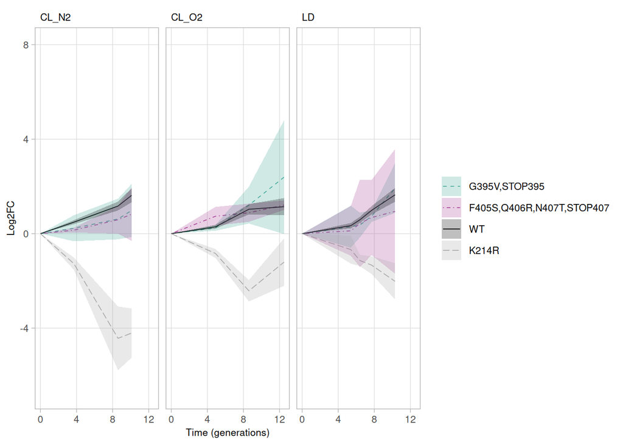

```r
truncated_subset <- combi_single_subset <- subset(fitness_data, fitness_data$sgRNA_target %in% c("G395V,STOP395", "F405S,Q406R,N407T,STOP407", "WT", neg_control_K214))
truncated_subset$sgRNA_target <- factor(truncated_subset$sgRNA_target, levels=c("G395V,STOP395", "F405S,Q406R,N407T,STOP407", "WT", neg_control_K214))
different_colors_set <- c("G395V,STOP395"="#44aa99ff", "F405S,Q406R,N407T,STOP407"="#aa4499ff", "WT"="black", "K214R"="darkgray")
different_linetypes_set <- c("G395V,STOP395"=44, "F405S,Q406R,N407T,STOP407"=1343, "WT"="solid", "K214R"="longdash")
p <- lineplot_CVinterval_severalColours_meanlog2(truncated_subset) + scale_linetype_manual(values=different_linetypes_set) + scale_color_manual(values=different_colors_set) + scale_fill_manual(values=different_colors_set)
ggsave("../lfcSE_weighted_outputImages/pdf/truncated_variants_performing_well.pdf", plot=p, height=1.75, width=6, units="in")
p
```

# Print tables with mutational effect of single amino acid exchanges

```r
single_muts <- unique(subset(fitness_data, fitness_data$number_muts==1 & fitness_data$condition=="CL_N2")[,c("sgRNA_target", "norm", "sd_fitness", "p_fit_adj_WT", "num_barcodes")])
write_csv(single_muts, "../lfcSE_weighted_outputImages/heatMap/single_muts_CLN2.csv")

single_muts <- unique(subset(fitness_data, fitness_data$number_muts==1 & fitness_data$condition=="CL_O2")[,c("sgRNA_target", "norm", "sd_fitness", "p_fit_adj_WT", "num_barcodes")])
write_csv(single_muts, "../lfcSE_weighted_outputImages/heatMap/single_muts_CLO2.csv")

single_muts <- unique(subset(fitness_data, fitness_data$number_muts==1 & fitness_data$condition=="LD")[,c("sgRNA_target", "norm", "sd_fitness", "p_fit_adj_WT", "num_barcodes")])
write_csv(single_muts, "../lfcSE_weighted_outputImages/heatMap/single_muts_LD.csv")
```

# Create files for ProteinNPT

Compare https://github.com/OATML-Markslab/ProteinNPT. Expects a .csv file. “At a minimum this file requires 2 fields: mutated_sequence (full sequence of amino acids) and DMS_score (assay measurement). If no fold variable is included in the assay file, the pipeline script will automatically create a fold_random_5 variable, assigning each mutant to folds 0-4 at random. You may also use your own cross-validation scheme (eg., assign all training sequences to fold 0, all test sequences to fold 1). To that end, you only need to pass to the pipeline script the name of that fold variable via the fold_variable_name argument and specify the index of the test fold via the test_fold_index argument (if test_fold_index is not passed as argument, the script will automatically perform a full cross-validation, rotating the test fold index at each iteration).”

Create a file for a) predicting higher-order combinations - separate amino acid positions into 5 folds –> add folds using python - three files for each condition

Use python script single_muts_train_for_combi.py to assign folds for training etc., output saturational_proteinNPT_with_foldChange.csv

Regarding folds: “We develop 3 distinct cross-validation schemes to assess the ability of each model to extrapolate to positions not encountered during training. In the Random scheme, commonly-used in other supervised fitness prediction benchmarks [Rao et al., 2019, Dallago et al., 2022], each mutation is randomly allocated to one of five distinct folds. In the Contiguous scheme, the sequence is split into five contiguous segments along its length, with mutations assigned to each segment based on the position they occur in the sequence. Lastly, the Modulo scheme uses the modulo operator to assign mutated positions to each fold. For example, position 1 is assigned to fold 1, position 2 to fold 2, and so on, looping back to fold 1 at position 6. This pattern continues throughout the sequence. We note that there is no inherent issue with using a Random cross-validation scheme to estimate the performance of predictive models. However, the conclusions drawn and the generalizability claims based on it require careful consideration.” –> use modulo scheme for assigning folds to saturational library

2. predicting more combinations
- how to assign folds? take modulo folds from saturational, combine combinatorial part and saturational part in the end

```r
saturational_for_proteinNPT <- unique(subset(fitness_data, fitness_data$number_muts==1)[,c("sgRNA_target", "norm", "baseAA", "condition")])
saturational_for_proteinNPT <- pivot_wider(saturational_for_proteinNPT, names_from=condition, values_from=norm)
write_csv(saturational_for_proteinNPT, "../lfcSE_weighted_outputImages/csv_for_proteinNPT/saturational_for_proteinNPT.csv")

all_for_proteinNPT <- unique(subset(fitness_data, fitness_data$number_muts>1)[,c("sgRNA_target", "norm", "condition")])
all_for_proteinNPT <- pivot_wider(all_for_proteinNPT, names_from=condition, values_from=norm)
write_tsv(all_for_proteinNPT, "../lfcSE_weighted_outputImages/csv_for_proteinNPT/combinatorial_for_proteinNPT.tsv")
```

# Create file for Supplement

```r
columns_for_table <- c("sgRNA_target", "num_barcodes", "number_muts", "norm", "condition", "p_fit_adj_WT", "EVcoup_predict", "DeepSeq_predict", "MSA_Transform", "proteinNPT_predict", "additive_score", "conservationScore", "absSAS", "relSAS", "dimer")

long_format <- unique(fitness_data[,columns_for_table])
write_csv(long_format, "../lfcSE_weighted_outputImages/SuppTable_all_fitness_values_long.csv")

wide_format <- pivot_wider(long_format, names_from=condition, values_from=c(norm, p_fit_adj_WT))
write_csv(wide_format, "../lfcSE_weighted_outputImages/SuppTable_all_fitness_values_wide.csv")
```